# 再论不平等的起源

## 5.9 那么真实世界在哪里

模型的相变已有自己的坐标。把国家放进来，要比较的是形状：财富集中长在顶端，还是大量人口的净财富接近零或为负？UBS 的人均成人财富口径不等于本章的非负、归一化财富过程，不能把国别基尼投到 $\sigma$ 轴上 (UBS 2023)。

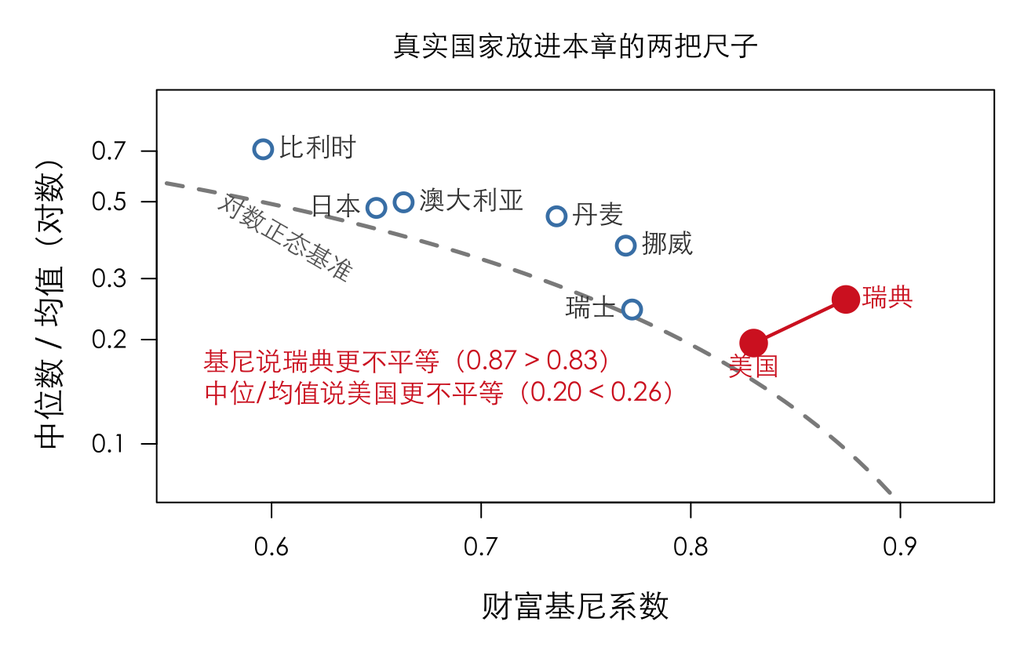

```r
ACC <- "#D62728"; BLU <- "steelblue"
## UBS Global Wealth Report 2023（2022 年末，家庭净资产口径，美元/成年人）
cty <- data.frame(
  nm   = c("美国", "瑞典", "瑞士", "挪威", "丹麦", "日本", "比利时", "澳大利亚"),
  mean = c(551347, 296800, 685226, 385338, 409954, 216078, 352814, 496819),
  med  = c(107739,  77515, 167353, 143887, 186041, 103681, 249937, 247453),
  G    = c(0.830, 0.874, 0.772, 0.769, 0.736, 0.650, 0.596, 0.663))
cty$mm <- cty$med/cty$mean
for(j in seq_len(nrow(cty))) {
  reg(paste0("country_gini_",j), cty$G[j], "derived", "§5.9 real_world", "UBS 报告输入值")
  reg(paste0("country_mm_",j), cty$mm[j], "derived", "§5.9 real_world", "UBS 中位财富除以平均财富")
}

par(mar = c(4.8, 5.2, 3.0, 1.0), cex.lab = 1.25, cex.main = 1.12, family = "cjk")
plot(NA, xlim = c(0.56, 0.93), ylim = c(0.075, 0.95), log = "y", yaxt = "n",
     xlab = "财富基尼系数", ylab = "中位数 / 均值（对数）",
     main = "真实国家放进本章的两把尺子")
axis(2, at = c(0.1, 0.2, 0.3, 0.5, 0.7), labels = c("0.1","0.2","0.3","0.5","0.7"), las = 1)

## 对数正态基准：给定基尼，若分布正好是对数正态，中位/均值应落在这条线上
gg <- seq(0.55, 0.95, by = 0.005); sg <- sqrt(2)*qnorm((gg + 1)/2)
lines(gg, exp(-sg^2/2), col = "gray55", lwd = 2.6, lty = 2)
text(0.607, 0.395, "对数正态基准", col = "gray40", cex = 1.0, srt = -30)


hi <- cty$nm %in% c("美国", "瑞典")
arrows(0.830, 0.195, 0.874, 0.261, code = 3, length = 0.08, lwd = 2.2, col = ACC)
points(cty$G, cty$mm, pch = 21, cex = ifelse(hi, 2.2, 1.6),
       bg = ifelse(hi, ACC, "white"), col = ifelse(hi, ACC, BLU), lwd = 2.4)
text(cty$G, cty$mm, cty$nm, pos = c(1, 4, 2, 4, 4, 2, 4, 4), cex = 1.05,
     col = ifelse(hi, ACC, "gray25"), font = ifelse(hi, 2, 1))
text(0.56, 0.148, paste("基尼说瑞典更不平等（0.87 > 0.83）",
                        "中位/均值说美国更不平等（0.20 < 0.26）", sep = "\n"),
     col = ACC, cex = 1.05, pos = 4)
```

基尼把瑞典排在美国之上：0.87 对 0.83；中位数与均值之比却把顺序倒过来：美国 0.20，瑞典 0.26。灰虚线是同基尼的对数正态基准；偏离方向显示出分布形状的差异。

美国顶端的集中与瑞典底部的零、负净财富不是同一件事。美国的财富上尾见 Saez 与 Zucman，瑞典的顶端与净财富分布见 Bengtsson 等 (Saez and Zucman 2016; Bengtsson et al. 2018)。这些研究与 UBS 的年份、样本和估计方法并不完全相同，可以解释量级与形状，不能拼成同精度的临界判据。

两国净资产口径都不计入公共养老金权益，而瑞典普通家庭的一生资源更依赖公共与职业年金。补入这些权益可能改变排序；没有两国可比的 augmented wealth 估计，这里只指出口径，不能报修正后的数。

趋势也不能换算成“离崩溃还有几年”：本章没有估计国家的 $\sigma$，没有从政策、制度到该参数的映射，也没有人口规模与时间的校准。因而把顶端份额线性外推到任意一条线，或用模型临界附近的行为推断现实加速，都没有推断依据。

同一量级的基尼，可以是底部塌陷，也可以是顶端集中。一条曲线，两道边界回答的是本模型的动力学问题；把基尼系数翻译成分布：一张换算表回答的是截面形状问题。两个答案各自明确，不能相互冒充。

## 5.10 最先到的不是崩溃，是程序公平失去正当性

这一整章只回答了一个问题：最坏能坏到什么程度。但答案里最要紧的一条不在那四道极限本身：

> 崩溃不是追求平等的理由——因为它多半不是最先会到的那件事。

这一章讨论的四重极限全是经济学意义上的：统计量失效、个体沉没、集体消失、交换停止。它们共享一个隐含前提：社会会一直安静地按同一套规则跑下去，直到数学上跑不动为止。这个前提是假的，而现实中的人可以要求改写规则。

第 3.4 节量过一件事：把储蓄率改成因人而异，指数尾就变成幂律尾。这句话要按它的口径读——它说的是“那一个特定的异质化改动会改掉尾巴”，不是“任何异质规则都长幂律尾”（保持细致平衡的异质相遇率就可以给出同一个平衡态），也不是“同质规则就一定不能均等化”：把每个人都换成 $w\mapsto(1-\tau)w+\tau\bar w$（人人按同一比例交一笔，再按人头分回去），规则对所有人一字不差、总量分文不动，基尼却精确地乘以 $1-\tau$；本章那个合并劈分本身也是一个同质的均等化机制。决定结局的是具体那条转移规则，不是“同质／异质”这个标签。但这里确实有一处不对称，一直没有说破：

> 程序公平本身什么也不保证；只有指定的那条基线交换规则才给出 0.5——而即使在它之下，也只保证基线存在，不保证从别处回到基线。

一座从零开始、只有随机搅拌的岛，程序公平把它带到 0.5。而一个已经站在 0.83 的社会，继续维持程序公平并不会把它带回 0.5——因为把它推到 0.83 的那些机制（第 6 章那一整族：资本回报、信贷、继承）本身全都是在程序公平之下运行的。规则确实对所有人一字不差地写着“资本按比例增值”，而这条一字不差的规则，正是第 4.3 节那个乘性结构。

于是对站在下半部分的人来说，程序公平从一个保护变成了一个锁。

这时候可以理解的回应，是要求换规则。具体说：从要求程序公平转向要求结果公平。注意这不等于放弃“规则对所有人一样”——上面那个「同比例征收、再按人头返还」就是反例：它对所有人同样适用，却把基尼乘上 $1-\tau$。要换的是转移规则本身，不必是规则的同质性。这在模型里不是道德判断，是一个机制推论：当程序公平的结果不可接受、而程序又不能自行修正结果时，唯一还能动的旋钮就是程序本身。

这件事人类学里有名字，也就是本文用过的 Boehm 的反向支配等级：多数人结成联盟，用一套明确不对称的规则，把任何试图爬上去的个体按回去 (Boehm 1999)。狩猎采集社会的平等不是程序公平的产物，恰恰是系统性违反程序公平的产物。（这是那条具体路径——反向支配等级本身就是不对称的；不是说均等化只能走不对称这一条路。）

### 5.10.1 模型到这里为止

上面那段推论的形式是：*在一个已经远离基线、而把它推离基线的机制本身又合乎程序的社会里，会出现要求更换转移规则的压力。*（更换规则不必意味着放弃“规则对所有人一样”——前面那个同比例征收再按人头返还的规则就是同质的。） 这是机制解释，模型没有内生的政治行动变量，不能把压力是否出现当成已经证明的预测。

它不能说的是：现实中哪些具体的社会运动是这种压力的表现。那是一个经验问题，而且任何一场真实冲突都有多重来源——身份、宗教、地域、代际、文化——未必都能归到财富分布上。把当代政治里某一场具体的争论直接读成“底层自救”，是把一个机制骨架当成了完整解释。

但有一层区分，模型能提供，而直觉往往把它们混在一起。面对同一个“结果不平等”，有两种诊断，形式上完全不同：

- 诊断一：规则本来就不同质——历史上就对某些人不一样，所以要做的是恢复同质性。
- 诊断二：规则确实同质，但同质规则本身是乘性的——所以要做的是换掉那条转移规则去抵消它。手段可以是同质的（对所有人一样的再分配），也可以是不对称的（只针对顶端）；模型只说“必须动规则”，不说必须动到哪一边。

两者在公共讨论里常被当成一件事，但它们要求的操作不同、代价不同、失败模式也不同：诊断一做过头会造出新的不对称，诊断二做不够则等于什么都没做。本文不判断哪一种在哪个场合成立——模型只能指出这是两件事，不能替谁选。

第三件能提供的是一个提醒：如果一个社会的公共讨论里，“程序公平”和“结果公平”之间的张力突然变得尖锐，那未必是价值观变了，可能只是分布变了。同一套价值观，放在基尼 0.5 的社会和放在基尼 0.83 的社会里，会指向不同的政策。

### 5.10.2 这个方向上已有的量化文献

Turchin 的结构人口理论把社会政治不稳定建模成三个前兆的函数：大众贫困化、精英过剩、国家财政困境——其中第一个与本章的“中位/均值塌陷”不是同一件事，方向也不保证一致——中位/均值是个比值：它可以在中位实际财富大幅上升时下降，也可以在所有人都变穷时保持不动。要说“大众贫困化”，得另外拿实际生活水平的证据 (Turchin 2016)。Scheidel 从历史一侧给出一个更冷的结论：过去两千年里真正大幅压低过不平等的只有四件事——战争、革命、国家崩溃、瘟疫 (Scheidel 2017)。

两边合起来是一个不舒服的推论：不平等很少被和平地压低。而第 6 章会量出一件更麻烦的事：再分配并不天然指向压低——它的符号取决于税基覆盖谁、支出流向谁，而这两项恰恰是权力最先介入的地方。

于是本文开头那一问，到这里要倒过来问。卢梭问“不平等的起源”，而这个提问方式本身有个盲点：在动物界，等级制才是常态。狒狒、黑猩猩、狼群、鸡群都有稳定的支配序列，位次决定谁先吃、谁能繁殖。人类的狩猎采集社会却异常地平等——而上面已经说了，那份平等靠的是系统性地违反程序公平。

> 不是不平等从哪来，而是平等从哪来。不平等是默认值——本文已经证明，连一条绝对程序公平的规则都会自动产出 0.5 的基尼系数，而真实世界站在 0.83；平等才是要花力气维持的成就。

那么这份力气买来了什么？这一问本文不答，因为它是姊妹篇《公平与效率：同一个温度》的正题：公平不是效率的对立面，而是对不确定性的正确定价。顺着那条线看，Boehm 的反向支配等级正好是一台维持高温的社会装置——多数人结盟压制独占，等于往系统里强行注入变异，而在“没人知道谁行”的世界里，那恰恰是效率最优的做法。压制独占不是为了避免崩溃，是因为它划算。那条论证在那边展开。

# 6 人类不平等的起源还有哪些，以及能改动什么

先把前面已经量到的东西收拢一次。到这里为止，本文并不是只讲了“随机搅拌”一件事——从第 3 章起，每换一个零件就多出一个机制，已经量过四条：

| 机制 | 在哪一章 | 平衡态 | 基尼系数 |
| --- | --- | --- | --- |
| 守恒 + 加性 + 无偏（基线） | 第 2–4 章 | 指数 | 0.50 |
| 全民储蓄一半再交换 | 第 3.4 节 | Gamma | 0.27 |
| 储蓄倾向因人而异 | 第 3.4 节 | 幂律尾 | 0.758 |
| 赌注按财富比例（yard-sale） | 第 4.3 节 | 不存在（凝聚） | → 1 |
| 资本回报带随机性 σ | 第 5 章 | 幂律尾 | 0.67（σ=0.6）／0.92（σ=1.2） |

这几条有一个共同点：它们全都是在同一台机器上换零件——换的是“每次拿多少出来换、自己留多少、钱会不会自己生钱”，全是交换规则内部的参数。而光是这些参数，就已经把基尼从 0.27 铺到接近 1。

里面还藏着两条规律，这一章会反复撞见：

- 凡是把基尼推高的，机制都是乘性的——按比例下注、按比例生息、储蓄率因人而异（它让财富的增长率因人而异，同样是乘性）。加性的公平停在 0.5，乘性的公平不停。
- 凡是把基尼压低的，要么打破了守恒，要么加了一根回复力——全民储蓄就是给每个人的财富拴上一根弹簧，把他往自己原来的位置拉。

这一章加的是机器之外的东西。卢梭列的两类（天赋、制度）、现实里的信贷与继承与通胀、以及模型里根本没有而现实中天天在用的税收——它们不是交换规则的参数，是社会制度。这一章把它们逐个放进同一个模型，量出各自值多少个基尼点，然后按方向分成三族：只会往上推的、方向取决于规则是否同质的、以及唯一一族可以由人主动选定方向的——而“选定”不等于“向下”。

```r
## 总图与三张分族图共用同一套画法与同一条横轴（0.2–1.0），分族图直接和总图对得上
UP <- "#D62728"; DN <- "#2C7BB6"; NEU <- "gray55"
draw_fmap <- function(FKEY, title){
  stopifnot(all(FKEY %in% names(REG)))                       # 缺一条就炸，不让图静默画错
  f <- data.frame(
    lab     = names(FKEY),
    g       = sapply(FKEY, function(k) REG[[k]]$v),
    kind    = sapply(FKEY, function(k) REG[[k]]$kind),
    neutral = sapply(FKEY, function(k) isTRUE(REG[[k]]$neutral)),
    stringsAsFactors = FALSE)
  f$d <- f$g - 0.5
  ## 排序纪律：点估计之间 0.001 的差别不构成有意义的排序。
  ## 按落点由高到低排，再把**整组跨度不超过 0.01 个基尼点**的相邻项并成一组
  ## （完全连接，不是逐差分组——否则 0.375/0.372/0.364 会被链成一组，总跨度 0.011 已超限），
  ## 组内按标签稳定排序，避免图上读出"累进税比最低保障更狠"这种由噪声造成的假名次。
  f <- f[order(f$g, decreasing = TRUE), ]
  grp <- integer(nrow(f)); gid <- 1L; anchor <- f$g[1]
  for (k in seq_len(nrow(f))){
    if (anchor - f$g[k] > 0.01){ gid <- gid + 1L; anchor <- f$g[k] }
    grp[k] <- gid
  }
  f <- f[order(grp, f$lab), ]
  n <- nrow(f); y <- n:1
  ## 中性只认显式标记（解析恒等，或效应区间覆盖 0）——不按"离 0.5 有多近"判
  neutral <- f$neutral
  col <- ifelse(neutral, NEU, ifelse(f$d > 0, UP, DN))

  par(mar = c(4.6, 0.4, 4.0, 0.4), cex.lab = 1.3, family = "cjk")
  plot(NA, xlim = c(-0.72, 1.06), ylim = c(-0.35, n + 1.9), axes = FALSE,
       xlab = "", ylab = "")
  axis(1, at = seq(0.2, 1.0, 0.1), cex.axis = 1.1)
  mtext("基尼系数", side = 1, line = 2.8, at = 0.6, cex = 1.3)
  abline(v = 0.5, lwd = 2.4, col = "gray30")
  text(0.5, n + 1.4, "基线 0.5（只有程序公平）", col = "gray25", cex = 1.12)
  for (k in seq_len(n)){
    segments(0.19, y[k], 1.04, y[k], col = "gray92", lwd = 1)
    if (neutral[k]) points(0.5, y[k], pch = 16, cex = 1.4, col = NEU)
    else arrows(0.5, y[k], f$g[k], y[k], length = 0.10, lwd = 3.2, col = col[k])
    text(0.175, y[k], f$lab[k], col = col[k], cex = 0.95, pos = 2)
    text(f$g[k] + ifelse(f$d[k] >= 0, 0.010, -0.010), y[k] + 0.32,
         sprintf("%.2f", f$g[k]), col = col[k], cex = 0.92,
         pos = ifelse(f$d[k] >= 0, 4, 2))
  }
  mtext(title,
        side = 3, line = 1.6, cex = 1.2, font = 2, adj = 0)
  text(0.21, -0.15, "更公平", col = DN, cex = 1.15, font = 2, pos = 4)
  text(1.03, -0.15, "更不平等", col = UP, cex = 1.15, font = 2, pos = 2)
  invisible(f)
}
## 21 行全部取自 REG——每个数字在它被算出的那一刻就地登记，此处只做引用
FKEY_ALL <- c(
  "赌注按财富比例（yard-sale）§4.3"                        = "yardsale",
  "能力谱：顶尖是中位的 1000 倍 §6.1.1"                      = "ability_sd3",
  "资本回报带随机性 σ = 1.2 §5"                            = "capital_12",
  "能力谱：顶尖是中位的 100 倍 §6.1.1"                       = "ability_sd2",
  "储蓄倾向因人而异 §3.4"                                  = "save_het",
  "能力谱：顶尖是中位的 10 倍 §6.1.1"                        = "ability_sd1",
  "随机择一继承（玩具设定）§6.2"                           = "inherit_random_single_heir",
  "资本回报带随机性 σ = 0.6 §5"                            = "capital_06",
  "增长按财富比例分配（任何 g）§6.2"                       = "growth_prop",
  "中性继承（一人接一份）§6.2"                             = "inherit_neutral",
  "通货膨胀（等比例贬值）§6.2"                             = "inflation_flat",
  "瘟疫：随机减员 30% §6.3"                                = "plague",
  "非豁免者纳税 + 支出流向精英（构造对照）§6.3.4"          = "cov_elite",
  "顶端豁免 + 按人头返还（同一税率）§6.3.4"                = "cov_exempt",
  "最低保障：托底 0.5× 均值 §6.3"                          = "floor_05",
  "累进税（税收总额 12%）§6.3"                             = "tax_progressive",
  "一次性没收顶端并返还（战争/革命）§6.3"                  = "confiscate",
  "诸子均分继承 §6.2"                                      = "inherit_partible",
  "每轮征税 40%，按人头返还 §6.3"                          = "tax40",
  "增长按人头平分（g = 1）§6.2"                            = "growth_flat",
  "全民储蓄一半再交换 §3.4"                                = "save_all")
```

先看总图。每一根箭头是一个实测出来的因素：从基线 0.5 出发，把基尼推到哪儿去，按幅度从大到小排。红色往右推，蓝色往左拉，灰点是实测不动的。每个数字在后面各节里逐个算出，第 6.5 节再回到这张图。

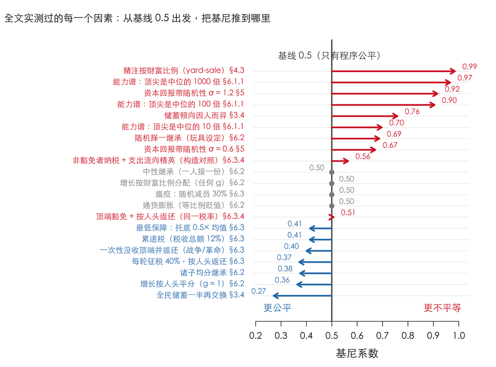

这一章分三族走：

- 只会往上推的：能力谱、资本回报、信贷。无论强弱都只有一个方向，区别仅在推多远。
- 方向取决于“它对所有人是否一样”的：继承、储蓄、通胀、增长。同一个机制，规则同质时是一个符号，因人而异时是另一个。
- 能主动拧的：再分配。它是唯一一族方向可以由人选定的——而“能选定”不等于“向下”。

三族走完，最后再看一个流传很广的说法——富人的投资。它不属于任何一族：消费和投资是加性与乘性的差别，而投资错误对基尼的符号，取决于错误落在谁头上。它放在三族之后、总图之前，作为一次横切的检查。

还有几样东西的效果根本不该用基尼去量，它们要紧的地方在别处（谁还在场、位置会不会换人），一并放到第 6.5 节交代。

下面按三族分开，逐个拆。

## 6.1 只会往上推的：能力、信贷、资本回报

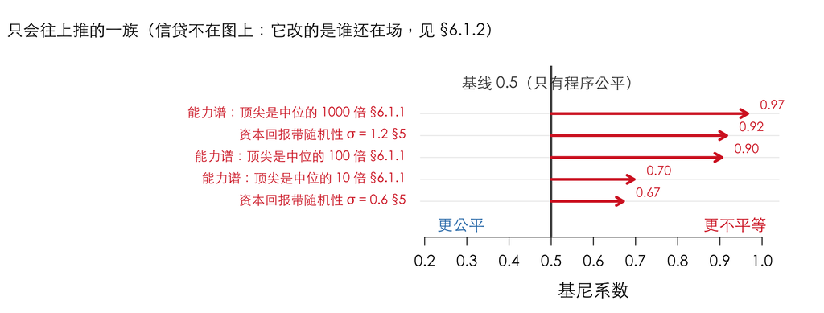

先看红色那一族。它们的共同点是只有一个方向——无论强弱，都只会把基尼往右推，区别仅在推多远。三样分开看：能力是卢梭判断“很小”的那个自然不平等，信贷是第 2 章那堵墙松动之后冒出来的，资本回报则是第 5 章那个旋钮在这一族里的位置。

### 6.1.1 能力：不是“小”，是一段跨行业的量级谱

先做一头一尾这两行：卢梭判断“很小”的那个自然不平等，和那个可以主动拧的旋钮。

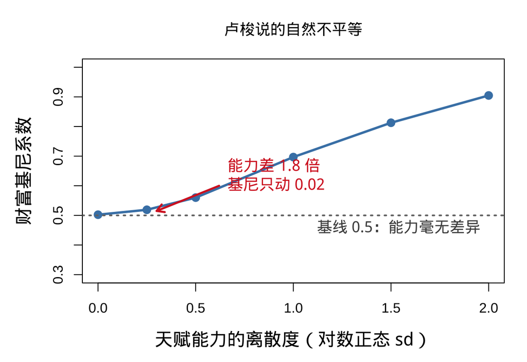

```r
## 同一条交换规则，只改一个零件
run1 <- function(N = 1500, rounds = 400, mode = "base", p = 0, seed = 1){
  set.seed(seed); w <- rep(1, N); half <- N/2
  a <- if (mode == "ability") exp(rnorm(N, 0, p)) else rep(1, N)
  a <- a/mean(a)                                  # 均值 1；p=0 时全为 1，退回基线
  for (r in 1:rounds){
    if (mode == "tax" && p > 0){ tx <- p*w; w <- w - tx + sum(tx)/N }   # 比例税 + 人头返还
    idx <- sample.int(N); i <- idx[1:half]; j <- idx[(half+1):N]
    pooled <- w[i] + w[j]
    ## 能力进入交换：分成比例 ~ Beta(a_i, a_j)，均分是它在 a≡1 时的特例
    e <- if (mode == "ability") rbeta(half, a[i], a[j]) else runif(half)
    w[i] <- e*pooled; w[j] <- (1 - e)*pooled
  }
  gini(w)
}
sds  <- c(0, 0.25, 0.5, 1, 1.5, 2, 3)          # 含 sd = 3，供下表的"1000 倍"那一行
g_ab <- sapply(sds, function(x) run1(mode = "ability", p = x))
## 换算表：sd -> 顶尖(99 分位)对中位的倍数 exp(2.33*sd)，以及基尼与它相对基线的增量
AB <- data.frame(sd = sds, mult = exp(2.33*sds), gini = g_ab)
AB$dG <- AB$gini - AB$gini[AB$sd == 0]
## 图只画到 sd = 2（sd = 3 越出这张图的量程，只进表）
pl <- AB$sd <= 2

ACC <- "#D62728"
par(mar = c(4.8, 5.0, 3.6, 1.4), cex.lab = 1.32, cex.main = 1.12)
plot(AB$sd[pl], AB$gini[pl], type = "o", pch = 16, cex = 1.4, lwd = 2.8, col = "steelblue",
     ylim = c(0.3, 1), xlab = "天赋能力的离散度（对数正态 sd）", ylab = "财富基尼系数",
     main = "卢梭说的自然不平等")
abline(h = 0.5, lty = 3, lwd = 2, col = "gray45")
text(2, 0.455, "基线 0.5：能力毫无差异", col = "gray30", cex = 1.12, pos = 2)
arrows(0.62, 0.60, 0.30, 0.515, length = 0.10, lwd = 2.4, col = ACC)
text(0.62, 0.62, sprintf("能力差 %.1f 倍\n基尼只动 %.2f",
     AB$mult[AB$sd == 0.25], AB$dG[AB$sd == 0.25]), col = ACC, cex = 1.15, pos = 4)
```

```r
for (k in c(1, 2, 3))
  reg(sprintf("ability_sd%d", k), AB$gini[AB$sd == k], "point", "§6.1.1 ability_sweep",
      sprintf("顶尖/中位 ≈ %g 倍", signif(exp(2.33*k), 1)))
## 自校验：能力谱三档与登记进 REG 的值一致（总图在 §6.5 直接读 REG）
stopifnot(all(is.finite(AB$gini)), all(diff(AB$gini) > 0))
```

自然不平等：不是“小”，是一个跨行业的量级谱。卢梭断言自然不平等“很小”，但那是拿动物打的比方。人不一样——人会用工具，还会结成组织（公司、学校、军队、行会），这两样东西把原始的能力差异乘性地放大，而且放大倍数因行业而异：

决定倍数的不是行业的名字，而是产出的结构——大致分三类：

- 产出受物理节奏封顶的工作：每单位时间做固定的动作，人体和工序卡着上限，最强的人也就比中等的人快一两倍。
- 产出可复制、边际成本近零的工作：一份成果做出来就能被复制无数次，于是能力差异被乘性地放大到十倍、百倍。
- 以“发现”为产出的工作：有人一辈子没找到什么，有人找到一件改变整个领域的东西。分母可以是零，所以比值根本没有上限。

工具和组织正是把第一类推向第二、三类的东西——它们让一个人的产出不再受自己的手脚限制。两者放大的方式不同，但做的是同一件事：工具把一个人的力气复制出去，组织把别人的劳动接到一个人的判断上。

所以正确的问法不是“自然不平等大不大”，而是“给定这个行业的能力谱，它能解释多少基尼系数”。上图 (a) 那条曲线就是这个换算表——横轴的对数正态 sd 可以直接读成“顶尖对中位的倍数”（$e^{2.33\,\mathrm{sd}}$）：

| 顶尖 / 中位 | 对数正态 sd | 基尼系数 | 能力额外贡献 | 大致对应 |
| --- | --- | --- | --- | --- |
| 1 倍（人人相同） | 0 | 0.50 | 0 | 岛屿基线：人人相同 |
| 2 倍 | 0.25 | 0.52 | +0.02 | 产出受物理节奏封顶 |
| 10 倍 | 1.0 | 0.70 | +0.19 | 产出可复制 |
| 100 倍 | 2.0 | 0.90 | +0.40 | 产出可复制、且放大更强 |
| 1000 倍 | 3.0 | 0.97 | +0.46 | 以“发现”为产出 |

读法要小心，但结论很清楚：

- 在能力谱窄的行业（差一两倍），那条 0.5 的基线压倒一切——观察到的不平等几乎全部来自随机搅拌，跟谁更能干无关。这一段卢梭猜对了。
- 在能力谱跨量级的行业，情况反过来：十倍差距就把基尼推到 0.70，百倍推到 0.90。这时能力才是主项，基线成了背景。

这里有一个必须交代的口径：本文的能力 `a` 是外生的、一次抽定、终身不变的。现实里不是——能力本身会被过往的资源分配塑造。这一条不是本文的发明，两边都有成熟的处理：

- 经济学一侧：Cunha 与 Heckman 的技能形成理论给了两个机制——自生产性（一期获得的技能会留到后面几期）与动态互补性（前期技能会抬高后期投资的产出）(Cunha and Heckman 2007)。要把它识别出来，靠的是重复测量加潜因子模型，需要纵向数据 (Cunha et al. 2010)。注意他们的状态变量是技能与投资，不是财富。
- 动理学一侧：把知识（或能力）和财富一起放进 Boltzmann 型模型的工作已经有一族。单向的——知识影响交易里的风险与储蓄参数 (Pareschi and Toscani 2014)；双向的——两个变量各自进入对方的碰撞规则，机制是“财富多的人被认为更可信，知识因而流向他”(Boudin and Trussardi 2024)。

本文两样都没做：`a` 只活在这一节和第 7 章的能力档里，不进入税收、继承、储蓄那些机制；它也不会被财富反过来改写。所以下面所有关于能力的话，都是在“能力外生”这个前提下说的。 - 所以“自然不平等 vs 制度不平等”这个二分在职业层面就已经不成立了——同一个社会里，两种机制的相对权重会因为“产出是怎么长出来的”而差好几倍。

这条曲线有一层限定，得就地说破。它属于这一个特定的约化式机制：能力经 `Beta(a_i, a_j)` 影响分账比例。而这个写法的方差是 $p(1-p)/(a_i+a_j+1)$——拧宽能力谱，在改变相对分账优势的同时也改掉了交换本身的噪声，两个效应混在一起。所以这张表读作“这台机器在这个能力谱下会走到哪里”是准的，读作通用的“产出能力 → 基尼”换算表就过头了。还有一层：`a` 在模型里是产出能力的约化式代理——岛上没有生产，“能力强 ⟹ 分账占优”这一步是设定的映射，不是本文推出来的。

还有一层卢梭看不到的：工具与组织是乘性放大器，而乘性正是把指数尾变成幂律尾的那台机器（给回报装上旋钮）。也就是说，人类特有的这两样东西，不只是把能力差异放大，还把不平等的分布形状从指数改成了幂律——那是量级上的改变，不是程度上的。

### 6.1.2 信贷：谁借得到，比借多少更要紧

这不是一条前提，是三条。第 2 章那堵墙一旦松动，冒出来的不是一个问题而是三个，而且它们的答案彼此独立：

1. 谁借得到？——额度按什么规则分配。
2. 能借多少？——额度多大。
3. 借不上怎么办？——财富为负之后，人还在不在场上。

三条分开测，结论差得很远。

```r
N <- 2000
run_credit <- function(mode, L = 1, rounds = 2000, seed = 2){
  set.seed(seed); w <- rep(1, N); alive <- rep(TRUE, N)
  vc <- runif(N) < 0.2                                   # 风投式：20% 的人凭"能力"拿到额度
  for (r in 1:rounds){
    id <- which(alive); if (length(id) < 4) break
    id <- sample(id); h <- floor(length(id)/2); i <- id[1:h]; j <- id[(h+1):(2*h)]
    lim <- switch(mode,
      none   = rep(0, h),                                # 无信贷
      flat   = rep(L, h),                                # 等额授信
      collat = pmax(w[i], 0),                            # 抵押式：额度 ∝ 自己的资产
      vc     = ifelse(vc[i], L, 0),                      # 风投式：与资产无关
      margin = rep(L, h))                                # 等额授信 + 触及 -L 即清算出局
    pay <- pmin(1, pmax(w[i] + lim, 0))
    w[i] <- w[i] - pay; w[j] <- w[j] + pay
    if (mode == "margin"){ d <- alive & (w <= -L); alive[d] <- FALSE; w[d] <- 0 }
  }
  sw <- sort(w, TRUE)
  c(top1 = 100*sum(sw[1:(N/100)])/sum(sw[sw > 0]), neg = 100*mean(w < 0),
    out = 100*mean(!alive), sdmu = sd(w)/mean(w))
}
CR <- sapply(c("none","flat","collat","vc","margin"), run_credit)
```

| 信贷制度 | 前 1% 占正财富 | 负债人口 | 被清算出局 | sd / 均值 |
| --- | --- | --- | --- | --- |
| 无信贷（本文基线） | 7.4% | 0.0% | 0.0% | 1.39 |
| 等额授信 | 9.2% | 33.1% | 0.0% | 2.48 |
| 抵押式：额度 ∝ 自己的资产 | 7.4% | 0.0% | 0.0% | 1.39 |
| 风投式：额度看能力，与资产无关 | 7.5% | 9.4% | 0.0% | 1.68 |
| 等额授信 + 触及下限即清算 | 43.7% | 0.0% | 96.6% | 5.79 |

第一条：谁借得到，比借多少更要紧。

- 抵押式（借款额随自己的资产走）在这个模型里一点作用都没有——数字和无信贷那行一模一样。原因很直白：它只借给不需要借的人。手里为零的人抵押额度也是零，该换不出去还是换不出去；而资产多的人本来就付得出，额度对他没有意义。
- 风投式（额度看的是能力而不是抵押品，资产少的人也能拿到）几乎是中性的：前 1% 占有 7.5%，和基线 7.4% 几乎一样，但有 9% 的人处在负债状态——它把人留在了牌桌上，而没有放大差距。

这一条要诚实标注边界：在纯交换模型里，信贷只影响“付不付得出”。抵押贷款在现实中的杀伤力不在这儿，而在它能放大回报——借钱去投资，赚赔都按倍数走。那属于乘性机制，是给回报装上旋钮那个 $\sigma$ 的事，不是这一节。换句话说：杠杆的危害不在交换里，在回报里。

### 6.1.3 资本回报：已经量过，但位置要点破

投资这一条已经在别处了。“有钱才能投资、投资又生钱”通常被当成不平等的头号机制。在本文的框架里，它就是第 5 章那个乘性回报的旋钮——已经量过，而且是推高一族里最狠的一个（$\sigma$ 从 0 拧到 1.2，基尼从 0.5 到 0.92）。

不过“谁能投资”（投资门槛）单独拿出来时，方向并不确定，取决于资本回报里确定性的复利和随机的风险谁占主导：前者占优时，门槛把复利留给少数人，放大差距；后者占优时，门槛反而把风险敞口限制在少数人身上，整体离散度不升反降。这一条本文给不出确定的符号，也没有做过可登记的参数扫描。

不过这一条上有一份能说点话的数据。第 2.7 节那张表只取了 1983 与 2018 两行；把逐年那一列整个画出来，会看到“上层”这个集合的人数并不是单调爬升的——它跟着股市呼吸：

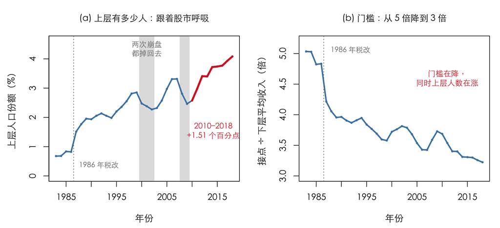

```r
## 上层这个集合的人数逐年怎么变。数据是 Ludwig-Yakovenko 随论文公开的逐年拟合参数，
## CC BY 4.0，来源与授权见 docs/data-external/ATTRIBUTION.md。
## 注意目录之分：docs/data/ 全是本文自己 knit 出来的结果（会跟基线逐格比对），
## docs/data-external/ 是外部只读数据，两者不能混。
stopifnot(file.exists("docs/data-external/ludwig-yakovenko-2022-params.csv"))
ucgLY <- utils::read.csv("docs/data-external/ludwig-yakovenko-2022-params.csv")
names(ucgLY)[1] <- "year"
ucgLY$fp_pct <- 100*ucgLY$fp                     # 上层人口份额，%
ucgLY$kT     <- ucgLY$rstar/ucgLY$T                 # 接点是下层平均收入的几倍
ucg_gy <- function(y, col) ucgLY[[col]][match(y, ucgLY$year)]

## 两次崩盘的回落，以及三个窗口的增幅——全部现算，正文只引用登记项。
ucg_win <- function(a, b) c(from = ucg_gy(a,"fp_pct"), to = ucg_gy(b,"fp_pct"),
                        d = ucg_gy(b,"fp_pct") - ucg_gy(a,"fp_pct"),
                        per = (ucg_gy(b,"fp_pct") - ucg_gy(a,"fp_pct"))/(b - a))
ucg_w80 <- ucg_win(1983, 1990); ucg_w00 <- ucg_win(2000, 2010); ucg_w10 <- ucg_win(2010, 2018)
## 自检：2010 年代必须是绝对增幅最大的窗口，且 2000 年代近乎持平——正文两句都靠这个。
stopifnot(ucg_w10["d"] > ucg_w80["d"], ucg_w10["d"] > ucg_w00["d"], ucg_w00["d"] < 0.2)

ucg_A <- "#D62728"; ucg_B <- "steelblue"; ucg_G <- "gray45"; ucg_SH <- "gray88"
par(mfrow = c(1, 2), mar = c(4.4, 4.6, 3.4, 1.0), cex.lab = 1.05, cex.main = 1.0,
    family = "cjk")

## (a) 上层人口份额：两次崩盘都掉回去，2010 之后是最陡的一段
plot(ucgLY$year, ucgLY$fp_pct, type = "n", xlab = "年份", ylab = "上层人口份额（%）",
     main = "(a) 上层有多少人：跟着股市呼吸", ylim = c(0, 4.6))
rect(1999.5, -1, 2002.5, 9, col = ucg_SH, border = NA)     # 互联网泡沫破裂
rect(2007.5, -1, 2009.5, 9, col = ucg_SH, border = NA)     # 全球金融危机
box()
lines(ucgLY$year, ucgLY$fp_pct, lwd = 2.6, col = ucg_B)
points(ucgLY$year, ucgLY$fp_pct, pch = 16, cex = 0.55, col = ucg_B)
ucg_seg <- ucgLY$year >= 2010
lines(ucgLY$year[ucg_seg], ucgLY$fp_pct[ucg_seg], lwd = 3.6, col = ucg_A)
text(2001, 4.35, "两次崩盘\n都掉回去", col = ucg_G, cex = 0.85)
text(2014.2, 1.55, sprintf("2010–2018\n+%.2f 个百分点", ucg_w10["d"]), col = ucg_A, cex = 0.88)
text(1986.5, 0.35, "1986 年税改", col = ucg_G, cex = 0.82, pos = 4)
abline(v = 1986.5, lty = 3, col = ucg_G)

## (b) 门槛：接点是下层平均收入的几倍，一路在降
plot(ucgLY$year, ucgLY$kT, type = "n", xlab = "年份", ylab = "接点 ÷ 下层平均收入（倍）",
     main = "(b) 门槛：从 5 倍降到 3 倍", ylim = c(3, 5.2))
lines(ucgLY$year, ucgLY$kT, lwd = 2.6, col = ucg_B)
points(ucgLY$year, ucgLY$kT, pch = 16, cex = 0.55, col = ucg_B)
abline(v = 1986.5, lty = 3, col = ucg_G)
text(1986.8, 5.05, "1986 年税改", col = ucg_G, cex = 0.82, pos = 4)
text(2011, 4.6, "门槛在降，\n同时上层人数在涨", col = ucg_A, cex = 0.88)
```

```r
for (y in c(1999, 2002, 2007, 2009)) reg(paste0("fp_", y), ucg_gy(y, "fp_pct"), "derived",
  "§6.1.3 upper_class_growth", paste("美国上层人口份额 %", y, "（Ludwig-Yakovenko 逐年参数）"))
reg("fp_w80_d",  ucg_w80["d"],   "derived", "§6.1.3 upper_class_growth", "1983-1990 上层人口份额增幅 pp")
reg("fp_w80_per",ucg_w80["per"], "derived", "§6.1.3 upper_class_growth", "同上，每年 pp")
reg("fp_w00_d",  ucg_w00["d"],   "derived", "§6.1.3 upper_class_growth", "2000-2010 增幅 pp")
reg("fp_w10_d",  ucg_w10["d"],   "derived", "§6.1.3 upper_class_growth", "2010-2018 增幅 pp")
reg("fp_w10_per",ucg_w10["per"], "derived", "§6.1.3 upper_class_growth", "同上，每年 pp")
reg("fp_1987_jump", ucg_gy(1987,"fp_pct") - ucg_gy(1986,"fp_pct"), "derived",
    "§6.1.3 upper_class_growth", "1986->1987 的跳升 pp，与《1986 年税改法案》同期")
```

图上有三件事可以直接读。

1. 两次崩盘，上层人口份额都掉了回去——2.85%（1999）落到 2.27%（2002），3.31%（2007）落到 2.46%（2009）。人不会在熊市里“退出资产阶级”——掉的是 AGI 里的已实现资本利得。这条线量的是流量，对行情高度敏感。
2. 2010–2018 是整个序列里绝对增幅最大的窗口：1.51 个百分点、每年 0.19 个百分点，而 2000–2010 那十年几乎是平的（0.10 个百分点）。1980 年代那一波每年 0.18 个百分点，速度相当，但那一波里有一跳是 1986→1987 的 0.69 个百分点，正撞在《1986 年税改法案》上——那更像申报行为变了，不是经济变了。这么算，2010 年代是这三十六年里最实在的一次扩张，而它恰好覆盖美股那轮十几年的长牛。

把税率摆上来，1986→1987 那一跳的形状就更清楚了。美国最高边际税率 1965–1980 年是 70%（其中 1972–1981 年劳动所得另封在 50%，那个 70% 主要落在非劳动所得上），1981 年 69.125%，1982 年降到 50%，1987 年 38.5%，1988 年 28% (Wilson 2002)——八年从 70% 掉到 28%。上层人口份额那次翻倍，正落在《1986 年税改法案》生效的第一年。

但“高税率压低了不平等”这个读法过不了一条算术。第 2.6 节那条 $G=(1+f)/2$ 按构造恒 $\ge 0.5$：顶端份额 $f$ 再小，基尼也只能趋近 0.5，压不到 0.5 以下。而实测在 1983–1986 年确实低于 0.5。所以那几年的低基尼不可能只是顶端被税削平造成的——要么主体本身比指数更平均，要么顶端那部分收入根本没进报税口径。

后一条更像真的，而且它说的不是“分配变了”。在 70%／50% 的税率下，高收入的合理反应是让收入不要以应税形式实现：递延薪酬、利润留在公司里、转成资本利得、走各种结构。税率一降到 38.5%，这些收入重新值得报出来——报税数据上“上层”于是突然多了一批人，而他们并不是那一年才变富的。这正是本节把那一跳算作申报行为、而不是经济变化的理由。

这对本文的用法有一个直接后果： 用报税数据量顶端，量到的是“顶端愿意以应税形式实现多少”，不是“顶端拥有多少”。 3. 门槛同时在往下走，右图那条线：接点从下层平均的 5.03 倍降到 3.22 倍。

于是很自然会想到一个解释：中产开始买股票了。这个猜测在本文的框架里属于对的那一类——获得一份乘性收入，正是跨过接点的方式。但这份数据不支持它，有两条理由：

- 参与率的时间对不上。美联储消费者财务调查（SCF）报的家庭持股比例（直接 + 间接）：2013 年 48.8%，2016 年回升到 51.9%，而 2016 年这个数才刚刚超过 2010 年的水平 (Bricker et al. 2017)。上层人数涨得最快的那几年，参与率正在低位。
- 更要紧的是口径。中产的股票绝大部分躺在 401(k)、IRA 这类递延账户里，取出来之前不进 AGI。所以哪怕参与率真的大涨，在这份报税数据上也几乎看不见。

同一份 SCF 里还有一个数把话说得更直白：2016 年最高收入组（前 10%）的持股率是 93.6%，全体是 51.9% (Bricker et al. 2017)。“谁能投资”这个问题，答案本身就极不平均——所以更可能的读法不是新人进场，而是本来就持有资产的人在牛市里把利得兑现，从而在那些年份越过接点。

原文作者的猜测是第三种，也摆上来。他们把上层的扩张归给经济数字化：平台业务是一对多的拓扑，能造出一批旧式本地生意造不出的超级富豪；同时他们明确把 2009 年之后那个尖峰归给量化宽松，并写下“美联储救市推高了不平等”(Ludwig and Yakovenko 2022)。

三种解释都指向资产市场，但落点不同——中产入场说落在人数，兑现说落在流量口径，数字化说落在顶端的形成机制。本文没有能力在三者之间裁决，所以这一条的符号照旧不给。但有一件事这张图已经说定了：这条阶级线的位置对资产市场高度敏感，而资产市场正是第 5 章那个 $\sigma$ 旋钮在现实里的名字。

第二条：额度越大，分布越宽。等额授信把前 1% 的占有从 7.4% 抬到 9.2%，标准差/均值从 1.39 涨到 2.48，33% 的人处在负债状态。上限继续放大，直到完全撤掉——那时平稳态不再存在，方差随时间无界增长。这一条和 Drăgulescu–Yakovenko 关于债务的结论一致 (Drăgulescu and Yakovenko 2000)。

第三条最狠，而且它跟“借多少”完全无关。把最后一行和第二行比：同样的额度 $L=1$，唯一的差别是触及下限之后会怎样。

- 弹回来（本文的设定）：33% 的人负债，但全都还在场上，位置随时可能改变。（说“翻身”要小心——模型里没有能动性，它只能说位置会换人，说不了谁靠什么换的。）
- 被清算（爆仓、强平、破产即出局）：96.6% 的人永久离场，前 1% 占到 43.7%。

同一条信贷额度，只因为清算规则不同，结果差了一个数量级。这正是第 2 章那两条前提的实验版——“墙在哪”决定分布有多宽，“墙是反射还是吸收”决定还有多少人在场。而后者的杀伤力远大于前者。

用一句话收：“能不能借到钱”决定差距的宽度，“借不上之后还算不算局中人”决定这个社会还剩多少人有机会。现实中的两种制度设计——破产保护与强制平仓——正好落在这条分界线的两侧。

## 6.2 方向取决于“它对所有人是否一样”：继承、储蓄、通胀、增长

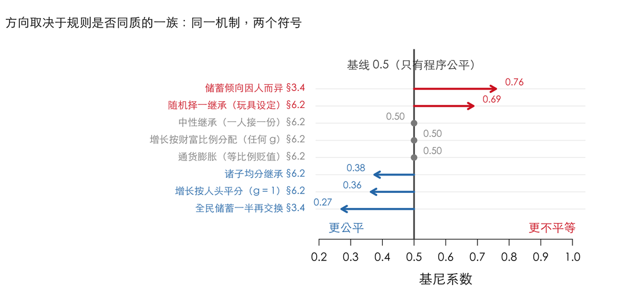

继承：基尼系数和流动性是两个独立的轴。每 300 轮换一代，比三种继承规则（同时量一个流动性指标：相邻两代财富排名的秩相关，越高越“世袭”）。两个量都在继承事件发生的那一刻测，父辈值取本人婚前财富：

```r
## 一代 = 300 轮交换；基尼与代际秩相关都在**继承事件发生的那一刻**测
## 父辈值 = 本人婚前财富，子女与父辈 1–1 配对（两参数规则下每个孩子对应一位父/母）
inherit_run <- function(regime, N = 4000, rounds = 300, G = 8, keep = 4, seed = 1){
  set.seed(seed); w <- rep(1, N); half <- N/2; gs <- rhos <- numeric(G)
  for (g in 1:G){
    for (r in 1:rounds){
      idx <- sample.int(N); i <- idx[1:half]; j <- idx[(half+1):N]
      pooled <- w[i] + w[j]; e <- runif(half); w[i] <- e*pooled; w[j] <- (1-e)*pooled
    }
    if (regime == "neutral"){ par_v <- w; ch <- w }
    else {
      idx <- sample.int(N); a <- idx[1:half]; b <- idx[(half+1):N]
      pool  <- w[a] + w[b]
      par_v <- c(w[a], w[b])
      ch <- if (regime == "partible") c(pool/2, pool/2)          # 两子各得一半
            else if (regime == "random_single_heir"){             # 两个槽位随机一个全得
                   u <- runif(half) < 0.5
                   c(ifelse(u, pool, 0), ifelse(u, 0, pool)) }
            else stop("unknown regime: ", regime)
    }
    gs[g] <- gini(ch); rhos[g] <- if (regime == "neutral") 1 else cor(rank(par_v), rank(ch))
    w <- ch
  }
  k <- (G - keep + 1):G                                            # 丢掉初始瞬态
  c(gini = mean(gs[k]), rho = mean(rhos[k]))
}
INH_R <- 12                                                        # 独立种子数
INH_raw <- lapply(c("neutral", "partible", "random_single_heir"), function(rg)
  t(sapply(1:INH_R, function(sd) inherit_run(rg, seed = 100 + sd))))
INH <- data.frame(
  regime = c("neutral", "partible", "random_single_heir"),
  gini = sapply(INH_raw, function(m) mean(m[, "gini"])),
  glo  = sapply(INH_raw, function(m) unname(quantile(m[, "gini"], .025))),
  ghi  = sapply(INH_raw, function(m) unname(quantile(m[, "gini"], .975))),
  rho  = sapply(INH_raw, function(m) mean(m[, "rho"])),
  rlo  = sapply(INH_raw, function(m) unname(quantile(m[, "rho"], .025))),
  rhi  = sapply(INH_raw, function(m) unname(quantile(m[, "rho"], .975))),
  stringsAsFactors = FALSE)
## 两条自校验：中性按构造 rho ≡ 1；诸子均分是两个独立指数变量取均值，基尼的解析值是 3/8
stopifnot(INH$rho[1] == 1, abs(INH$gini[2] - 3/8) < 0.01, abs(INH$gini[1] - 0.5) < 0.01)
reg("inherit_neutral", INH$gini[1], "mean", "§6.2 inheritance",
    sprintf("%d 个种子；继承映射是恒等式，效应解析上为零", INH_R), neutral = TRUE)
reg("inherit_partible", INH$gini[2], "mean", "§6.2 inheritance", "解析值 3/8")
reg("inherit_random_single_heir", INH$gini[3], "mean", "§6.2 inheritance", sprintf("%d 个种子", INH_R))
```

| 继承规则 | 基尼系数 | 代际秩相关 | 读法 |
| --- | --- | --- | --- |
| 一人接一份，原封不动（本文基线） | 0.500 | 1.00 | 位置完全冻结 |
| 夫妻合并、诸子均分 | 0.375 | 0.67 | 不平等降，流动性升 |
| 随机择一继承（玩具设定） | 0.687 | 0.18 | 不平等最高，流动性也最高 |

（数字都是多种子的均值：跑 8 代、丢掉初始瞬态只取后 4 次代际转移，12 个独立种子。诸子均分那一行有解析解可对照——两个独立指数变量取均值，基尼恰好是 $3/8$。）

这三行推翻了一个常见的直觉——“不平等高就等于阶层固化”。基尼定不住阶层流动性：诸子均分把基尼压低、流动性抬高；而随机择一继承把基尼推到 0.69，流动性反而是三行里最高的。同一个方向的基尼变化可以配上相反的流动性变化，所以基尼根本测不出“位置会不会换人”，那需要另一个量。（第三行的名字要照字面读：两个孩子只是配对的两个槽位，随机一个拿走全部。模型里没有出生顺序，也没有跨代身份。）

现在可以回去和第 4.6 节那条盖茨比曲线算账了。跨国数据说的是“基尼越高、阶层流动性越低”，上面这张表看起来在唱反调。但先把账算准：三行里只有一行真的反向。

- 基线 → 诸子均分：基尼 0.500 → 0.375，代际秩相关 1.00 → 0.67（流动性升）。不平等降、流动性升，这和盖茨比曲线同向。
- 基线 → 随机择一继承：基尼 0.500 → 0.687，代际秩相关 1.00 → 0.18（流动性也升）。不平等升、流动性也升——只有这一行反向——而它恰好是三行里唯一“整份传给一个人”的那行。财富不切分，子代的位次就由一次抛硬币定，与父辈的位次脱钩；流动性因此不降反升。

所以“模型和盖茨比曲线打架”这个印象，很大程度上来自一个被高估的流动性数字。即便如此，两者也谈不上矛盾，因为它们不是同一类陈述：Corak 那张图是不同社会之间的截面相关，这张表是同一个模型里只换一个零件的比较静态；何况纵轴也不是一回事——他量的是代际收入弹性，本文量的是代际秩相关，方向可比，数值不可比。

### 6.2.1 那到底是什么把不平等和阶层流动性绑在一起

模型证明了基尼和阶层流动性之间没有必然的函数关系，所以跨国数据里那条清楚的正相关不可能来自两者的机械联系。它必须来自某个同时推高不平等、又同时降低流动性的共同原因。经济学里对这个共同原因有一个成熟的答案，而且它正好穿过第 6.1.2 节已经量过的那根杠杆。

Becker–Tomes 的机制，经 Solon 整理成可检验的形式 (Becker and Tomes 1979; Solon 2004)：父母会为孩子投资（教育、健康、时间、门路），而这笔投资的回报率取决于社会给技能的溢价。技能溢价一高，两件事同时发生：

1. 不平等上升——同样的能力差异换来更大的收入差距；
2. 投资的诱因上升——但投不投得起取决于父母手里有多少钱，因为没有人能拿孩子未来的收入去抵押借钱。

于是技能溢价这一个参数，同时把基尼推高、把阶层流动性压低。它们不是互为因果，是同一个原因的两个后果。

这个机制可以直接跑出来。设投资的目标额随回报率 $\gamma$ 上升，孩子的收入 $=A\cdot(1+I)^{1.5}$（$A$ 是与父母无关的独立能力冲击），再比三种投资体制：

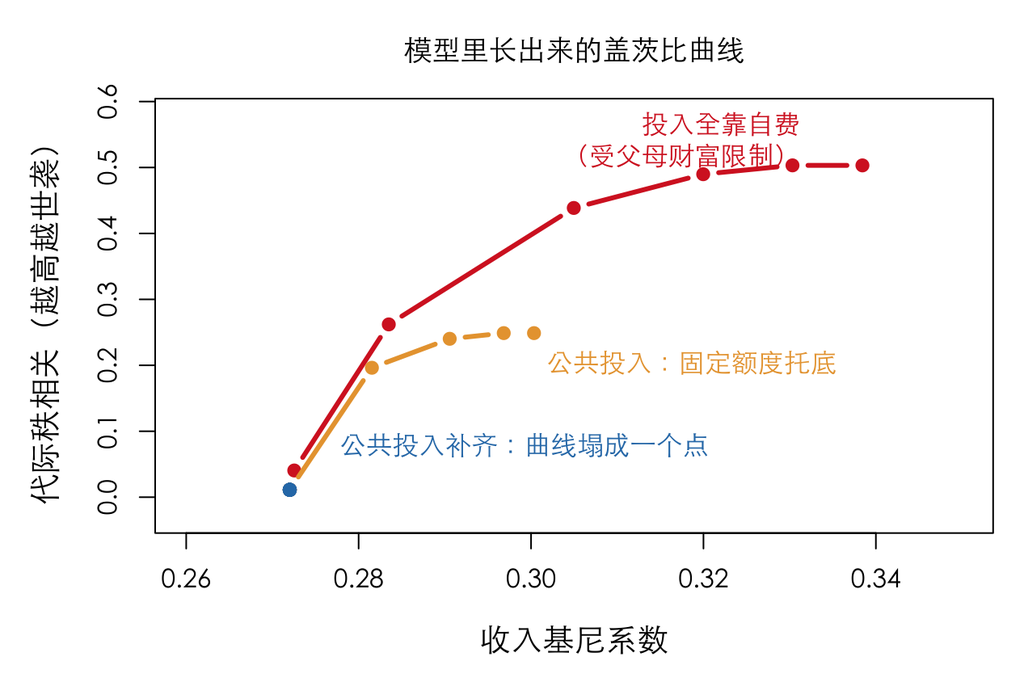

```r
gats <- function(gamma, regime, N = 4000, gens = 15, kappa = 0.6, sda = 0.5, seed = 1){
  set.seed(seed); y <- rep(1, N); Istar <- gamma      # 目标投入随回报率上升
  for (g in 1:gens){
    priv <- pmin(Istar, kappa*y)                      # 自费：投得起多少看父母有多少
    I <- switch(regime,
                none = priv,                          # 全靠自费
                floor_ = pmax(0.6, priv),             # 公共投入：固定额度托底
                full = rep(Istar, N))                 # 公共投入：补齐到目标额
    A <- exp(rnorm(N, 0, sda)); yp <- y               # 与父母无关的能力冲击
    y <- A*(1 + I)^1.5; y <- y/mean(y)
  }
  c(gini = gini(y), rho = cor(rank(yp), rank(y)))
}
gam <- c(0.1, 0.3, 0.6, 1, 1.5, 2.5, 4)
RG  <- lapply(c("none", "floor_", "full"),
              function(rg) t(sapply(gam, function(x) gats(x, rg))))
names(RG) <- c("none", "floor_", "full")

COL <- c(none = "#D62728", floor_ = "#E8A33D", full = "#2C7BB6")
par(mar = c(4.8, 5.0, 3.2, 1.0), cex.lab = 1.22, cex.main = 1.1, family = "cjk")
plot(NA, xlim = c(0.26, 0.35), ylim = c(-0.03, 0.58),
     xlab = "收入基尼系数", ylab = "代际秩相关（越高越世袭）",
     main = "模型里长出来的盖茨比曲线")
for (nm in names(RG))
  lines(RG[[nm]][, 1], RG[[nm]][, 2], col = COL[nm], lwd = 3, type = "b", pch = 16, cex = 1.2)
text(0.333, 0.53, "投入全靠自费\n（受父母财富限制）", col = COL["none"], cex = 1.02, pos = 2)
text(0.300, 0.20, "公共投入：固定额度托底", col = COL["floor_"], cex = 1.02, pos = 4)
text(0.276, 0.075, "公共投入补齐：曲线塌成一个点", col = COL["full"], cex = 1.02, pos = 4)
```

而蓝点说明了因果的方向。把“投资额受父母财富限制”这一条拆掉——公共投入把每个孩子都补齐到目标额——整条曲线塌成一个点：技能溢价再高，基尼原地不动 0.272，代际秩相关也原地不动 0.01。把不平等翻译成低流动性的那台机器，是“投资额挂在父母财富上”这件事本身，而不是不平等。

这和第 6.1.2 节那条信贷结论是同一句话的两个版本：那边量到的是“谁借得到，比借多少更要紧”，这边量到的是“谁投得起，比技能溢价多高更要紧”。两次都是资格问题，不是额度问题。

橙线是中间地带，也最像现实。固定额度的公共投入在技能溢价不高时能把曲线完全压住；一旦溢价涨过那个额度，私人投资重新拉开差距，秩相关又爬起来——只是爬到 0.25 而不是 0.50。公共投入不是一个开关，是一个会被甩开的额度。这正是 Solon 的结论：代际弹性随“公共人力资本投入的累进性”下降 (Solon 2004)。

### 6.2.2 还有一层：那条曲线的纵轴自己带着不平等

最后一件容易被跳过的事。盖茨比曲线的纵轴是**代际收入弹性** $\beta$，而它和秩相关 $\rho$ 之间有一个恒等式：

$$\beta \;=\;
\frac{\mathrm{Cov}(y_c,\,y_p)}{\mathrm{Var}(y_p)} \;=\;
\rho\cdot\frac{\sigma_c}{\sigma_p}$$

其中 $\sigma$ 是各代收入对数的截面标准差，而这个式子里的 $\rho$ 必须是**对数收入的皮尔逊相关**，不是秩相关——本文别处量的代际秩相关（Spearman）代不进这个恒等式，非线性下两者能差两成以上。纵轴里本来就含着一个离散度之比。于是一个不平等正在上升的国家（$\sigma_c>\sigma_p$），哪怕对数收入的皮尔逊相关一点没变，量出来的 $\beta$ 也会偏高——横轴的东西漏进了纵轴。

这不否定那条曲线，上面的实验说明机制确实存在；但它解释了为什么改用秩–秩斜率重画时曲线会平缓一些，也再次印证第 4.6 节那句话：IGE 最好别单独用。

储蓄也是同一回事。第 3.4 节量过两次：所有人都存一半，基尼从 0.50 掉到 0.27；存钱的习惯因人而异，同一个机制把基尼推到 0.758。中间那个“人人相同”的版本是均等化力量，“因人而异”的版本是最强的推高力量之一——同一个零件，装法不同，符号相反。

通货膨胀是这一族里最干净的例子，而且它的第一层答案是“完全没有影响”。每轮让所有人的钱等比例贬值 $\pi$——这在数学上就是给整个分布乘一个常数，而基尼是尺度不变量，所以它一动不动。模拟给出的数和基线完全相同。这一点值得记住：纯粹的通胀不是再分配。

但现实里的通胀几乎从不是“纯粹”的，因为不同的人持有的东西不一样：越穷的人，财富里现金和存款的比例越高；越富的人，越多是随通胀一起涨价的资产。把这一条加进模型——只侵蚀现金部分、资产部分跟涨——通胀立刻变成一个推高的力量。

```r
N <- 2000; half <- N/2
ex <- function(w){ idx <- sample.int(N); i <- idx[1:half]; j <- idx[(half+1):N]
  pooled <- w[i] + w[j]; e <- runif(half); w[i] <- e*pooled; w[j] <- (1-e)*pooled; w }
infl <- function(mode, pi = 0, rounds = 800, seed = 1){
  set.seed(seed); w <- rep(1, N)
  for (r in 1:rounds){
    if (mode == "flat") w <- w*(1 - pi)                 # 全员等比例贬值
    if (mode == "cash"){ a <- w/(w + 1)                 # 资产份额随财富上升
      w <- w*a + w*(1 - a)*(1 - pi) }                   # 只有现金部分被侵蚀
    w <- ex(w); w <- w/mean(w)
  }
  gini(w)
}
INF <- c(`基线（无通胀）` = infl("none"),
  `全员等比例 2%` = infl("flat", 0.02), `全员等比例 10%` = infl("flat", 0.10),
  `只侵蚀现金 2%` = infl("cash", 0.02), `只侵蚀现金 10%` = infl("cash", 0.10))
## 等比例贬值再按均值归一，是恒等变换——基尼精确不变，不取某次实现的数值
reg("inflation_flat", 0.5, "analytic", "§6.2.2 inflation",
    "全员等比例：w(1-π) 归一后逐位相同", neutral = TRUE)
INF
```

```
## 基线（无通胀）  全员等比例 2% 全员等比例 10%  只侵蚀现金 2% 只侵蚀现金 10%
##      0.4879929      0.4879929      0.4879929      0.4904460      0.5015007
```

所以“通胀对穷人更不利”这句流行的话，准确的说法是：通胀本身中性，是持有结构让它变得不中性。而同一条结构差异反过来也成立——通胀会稀释债务，对负债的人是净利好。方向仍然取决于那句老话：它对所有人是不是同一回事。

增长：把蛋糕做大，本身不改变任何东西。这是这一族里最反直觉的一条，因为“做大蛋糕”通常被当作不平等问题的解药。放进模型跑一遍：每轮先增长 $g$，再照常交换，只换增量怎么分。

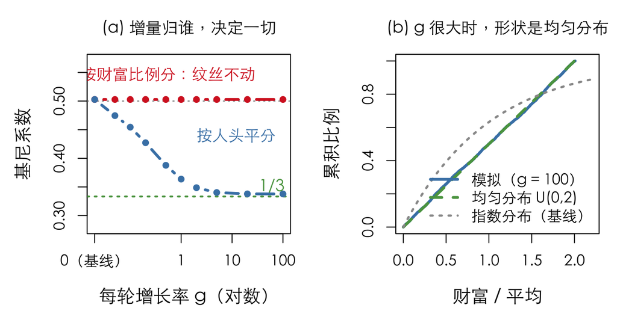

```r
grow <- function(rule, g, N = 4000, rounds = 1200, seed = 1){
  set.seed(seed); w <- rep(1, N); half <- N/2
  for (r in 1:rounds){
    if (rule == "prop") w <- w*(1 + g)        # 增量按各人财富比例分
    if (rule == "flat") w <- w + g*mean(w)    # 增量按人头平分
    idx <- sample.int(N); i <- idx[1:half]; j <- idx[(half+1):N]
    pooled <- w[i] + w[j]; e <- runif(half)
    w[i] <- e*pooled; w[j] <- (1-e)*pooled
    w <- w/mean(w)                            # 只为防溢出；基尼是尺度不变量
  }
  w
}
gs <- c(0, 0.05, 0.1, 0.2, 0.5, 1, 2, 5, 20, 100)
Gp <- sapply(gs, function(g) gini(grow("prop", g)))
Gf <- sapply(gs, function(g) gini(grow("flat", g)))
w100 <- grow("flat", 100)

ACC <- "#D62728"; BLU <- "steelblue"; GRN <- "#59A14F"
par(mfrow = c(1, 2), mar = c(4.6, 4.8, 3.0, 1.0), cex.lab = 1.2, cex.main = 1.08,
    family = "cjk")
xs <- pmax(gs, 0.02)
plot(NA, xlim = range(xs), ylim = c(0.28, 0.57), log = "x", xaxt = "n",
     xlab = "每轮增长率 g（对数）", ylab = "基尼系数", main = "(a) 增量归谁，决定一切")
axis(1, at = c(0.02, 1, 10, 100), labels = c("0（基线）", "1", "10", "100"))
abline(h = 0.5, lty = 3, col = "gray50"); abline(h = 1/3, lty = 3, col = GRN, lwd = 2)
reg("growth_prop", 0.5, "analytic", "§6.2.2 growth_rules",
    "同乘 (1+g) 只是换单位，基尼是尺度不变量，逐位相同", neutral = TRUE)
reg("growth_flat", Gf[which(gs == 1)], "point", "§6.2.2 growth_rules", "g = 1；g→∞ 的极限是 1/3")
lines(xs, Gp, col = ACC, lwd = 3, type = "b", pch = 16)
lines(xs, Gf, col = BLU, lwd = 3, type = "b", pch = 16)
text(0.55, 0.547, "按财富比例分：纹丝不动", col = ACC, cex = 1.05)
text(12, 0.44, "按人头平分", col = BLU, cex = 1.05)
text(60, 0.352, "1/3", col = GRN, cex = 1.1)

u <- sort(w100/mean(w100)); pp <- seq_along(u)/length(u)
plot(u, pp, type = "l", col = BLU, lwd = 3, xlim = c(0, 2.2),
     xlab = "财富 / 平均", ylab = "累积比例", main = "(b) g 很大时，形状是均匀分布")
lines(c(0, 2), c(0, 1), col = GRN, lwd = 3, lty = 2)
xe <- seq(0, 2.2, length.out = 200); lines(xe, 1 - exp(-xe), col = "gray60", lwd = 2.4, lty = 3)
legend("bottomright", c("模拟（g = 100）", "均匀分布 U(0,2)", "指数分布（基线）"),
       col = c(BLU, GRN, "gray60"), lwd = c(3, 3, 2.4), lty = c(1, 2, 3), bty = "n", cex = 1.0)
```

按财富比例分：基尼一个数字都不动。$g$ 从 0 拧到 100，基尼恒为 0.503——不是“变化很小”，是逐位相同。道理一行说完：所有人同乘 $(1+g)$ 只是换单位，而基尼是尺度不变量。增长一百倍和完全不增长，分布形状一模一样。

按人头平分：单调压低，但停在 1/3。$g$ 越大压得越狠，从 0.503 一路降到 0.338，此后再加多少都不动了。

这个 1/3 不是增长的性质，是交换本身的性质。把一群财富完全相等的人拿来，随机配对、两人的钱合起来随机劈分——一轮之后就是均匀分布，而均匀分布的基尼恰好是 $1/3$。右图验证了这一点：$g=100$ 时的累积曲线（蓝）几乎压在均匀分布那条直线（绿）上，离基线的指数分布（灰）很远。再分配能把输入压平，却压不住交换重新把它摊开。

这也解释了一件后面会撞上的事：第 6.3 节那个税收实验的下限同样是 1/3。两者钱的来源完全不同——一个是印出来的，一个是征来的——但在数学上是同一个操作：给每个人的财富加上同一个常数。

（第三种分法——按比例分，但回报带随机性——就是第 5 章那个 $\sigma$ 旋钮，已经量过：$\sigma=0.6$ 给基尼 0.67，$\sigma=1.2$ 给 0.92。所以“增长”这一条在三个方向上都能走。）

三条并排看，规律就出来了：

| 机制 | 对所有人一样时 | 因人 / 因规则而异时 | 另一个方向 |
| --- | --- | --- | --- |
| 储蓄 | ↓ 0.27（全民存一半） | ↑ 0.758（储蓄倾向异质） | — |
| 继承 | → 0.50（一人接一份） | ↑ 0.69（随机择一继承） | ↓ 0.375（诸子均分） |
| 增长 | → 0.50（按财富比例，纹丝不动） | ↑ 0.92（回报带涨落） | ↓ 0.36（按人头平分，g = 1；极限 1/3） |

这一族才是卢梭那条链的真正位置。他说不平等来自私有财产和法律，而这里能说得更准：不是“有没有这些制度”，而是“这些制度对所有人是不是同一套”。规则同质时它们中性甚至均等化；一旦因人而异，同一套制度立刻变成最强的放大器。

## 6.3 能主动拧的旋钮：再分配，以及它的两个方向

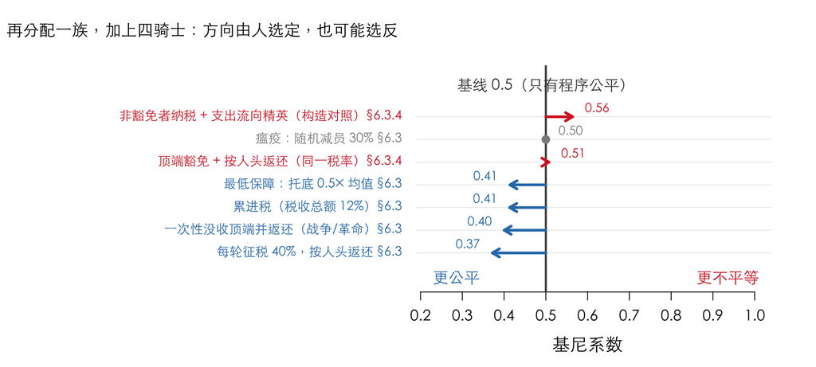

前面每一条都在描述“世界本来什么样”，只有这一条在问“我们能改成什么样”。最简单的版本：每轮按比例征走 $\tau$，收上来的钱按人头返还。

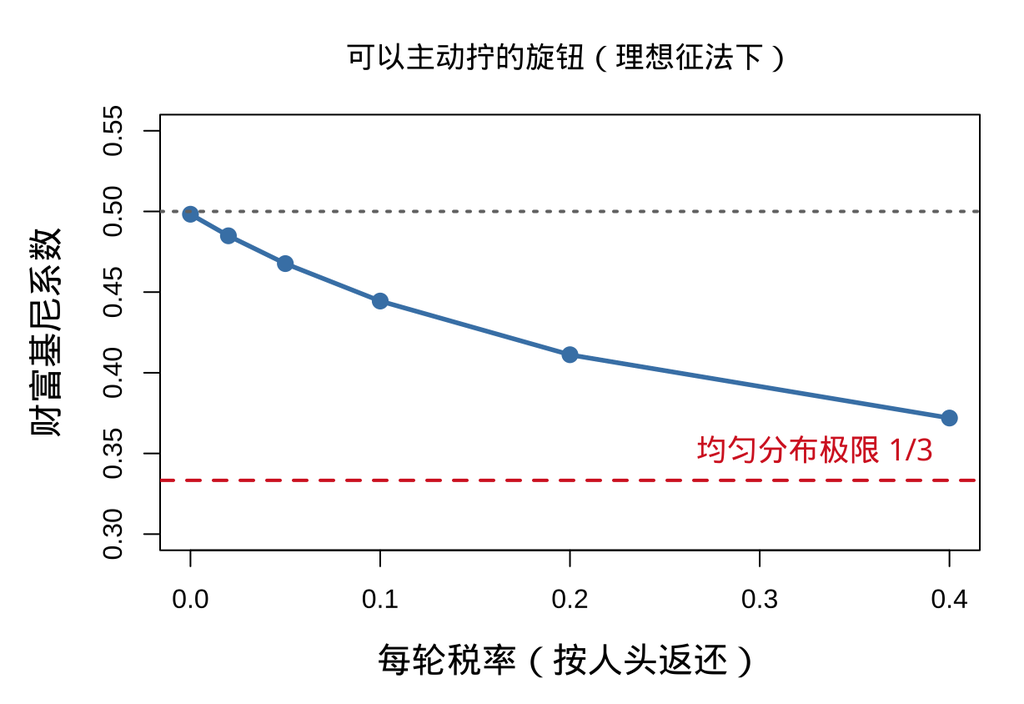

```r
taus <- c(0, 0.02, 0.05, 0.1, 0.2, 0.4)
g_tx <- sapply(taus, function(x) run1(mode = "tax", p = x))
reg("tax_tau_max", max(taus), "analytic", "§6.3 tax_sweep", "税率扫描的最高档（毛征收率）")
## 指数分布的 Pietra 有闭式 1/e；净转移份额 = 毛征收率 x Pietra
reg("tax_net_max", 100*max(taus)*exp(-1), "derived", "§6.3 tax_sweep", "最高档对应的净转移占总财富的百分比")

par(mar = c(4.8, 5.0, 3.6, 1.4), cex.lab = 1.32, cex.main = 1.12)
plot(taus, g_tx, type = "o", pch = 16, cex = 1.4, lwd = 2.8, col = "steelblue",
     ylim = c(0.3, 0.55), xlab = "每轮税率（按人头返还）", ylab = "财富基尼系数",
     main = "可以主动拧的旋钮（理想征法下）")
abline(h = 0.5, lty = 3, lwd = 2, col = "gray45")
abline(h = 1/3, lty = 2, lwd = 2, col = ACC)
text(0.4, 0.35, "均匀分布极限 1/3", col = ACC, cex = 1.15, pos = 2)
```

```r
reg("tax40", g_tx[6], "point", "§6.3 tax_sweep", "每轮征 40%，按人头返还（taus 第 6 档）")
```

税收：能压，但压不到零。每轮征走比例 $\tau$ 再按人头返还，基尼从 0.498 一路降到 $\tau=0.4$ 时的 0.372。方向对了，但有两处口径必须先讲清，否则这条曲线会被读成一个它并没说的结论。

一是测量相位。 `run1()` 每轮先征税返还、再做一次随机交换，报的是交换之后的基尼。所以这里的 $1/3$ 不是再分配能力的下限，而是再分配 + 一轮交换这个复合操作的不动点：$\tau=1$ 时紧接再分配基尼就是 0（人人拿到均值），随后那一轮池化劈分又把它推回 $1/3$。真正压不下去的不是税，是税后立刻又发生的那次交换。这和第 6 章按人头平分的增长撞上同一个极限，因为两者在数学上是同一个操作。

二是代价陡峭——在这个复合操作下，要把基尼压到 0.3 以下所需的税率高到不像政策而像没收。

### 6.3.1 全民普发现金：它和税收是同一件事吗？

是，但要看钱从哪来——而两种来处，通向同一个极限。

第一种：税筹的 UBI。按比例征税、再按人头等额发下去——这和本节开头那个 $\tau$ 不是相似，是同一个操作：先按比例抽走一块，再平均发回来。所以它的效果、代价、下限，前面已经全部量过了：$\tau=0.4$ 时基尼 0.372，而下限是 $1/3$。

第二种：印钞筹的 UBI。不征税，直接增发货币按人头发放。这在模型里对应的是第 6.2 节那一行——“按人头平分的增长”，实测把基尼压到 0.36，极限同样是 $1/3$。

两条路的极限撞在同一个数上，这不是巧合。无论钱是从上面征来的、还是从下面印出来的，只要它按人头平分，做的就是同一件事：往每个人的财富里注入一个相同的常数。而不断注入相同的常数，分布就被推向“两人总和的一次随机劈分”——也就是均匀分布，基尼 $1/3$。

> 所有“按人头平分”的操作，在数学上是同一个操作。它们的区别不在效果，而在钱从哪来。

但第二种有一个第一种没有的副作用，而且方向相反：印钞会带来通胀。上一节刚说过，纯粹的等比例通胀是完全中性的——那部分不影响结论；可一旦通胀主要侵蚀现金而非资产，它就成了一个推高的力量，会部分抵消普发现金的均等化效果。净效果取决于这两股力量谁大，而这取决于穷人和富人各自持有什么——又回到了那句老话。

最后标一条本模型的边界：这里只算了分配。现实中税筹和印钞对产出的影响完全不同（一个改变激励，一个改变价格），而本文的模型里根本没有生产，所以这一层它答不了。

### 6.3.2 另一个杠杆：把墙抬高（最低保障）

税收是“从上面拿”，还有一种是“从下面托”：设一条下限 $w_{\min}$，谁掉到线下就补到线上，钱按财富比例向全体征收。在第 2 章的语言里，这是把那堵反射墙从 0 抬到 $w_{\min}$。

```r
floor_run <- function(mode, p, rounds = 800, seed = 1){
  set.seed(seed); w <- rep(1, N); moved <- 0
  for (r in 1:rounds){
    if (mode == "tax"){ tx <- p*w; moved <- moved + sum(abs(tx - sum(tx)/N))/2
                        w <- w - tx + sum(tx)/N }
    else { mn <- p*mean(w); need <- pmax(mn - w, 0); moved <- moved + sum(need)
           if (sum(need) > 0){ w <- w + need; w <- w - sum(need)*w/sum(w) } }
    w <- ex(w); w <- w/mean(w)
  }
  c(gini = gini(w), moved = moved/rounds/N)
}
FL <- cbind(`普惠税 5%`  = floor_run("tax", 0.05),  `普惠税 15%` = floor_run("tax", 0.15),
            `托底 0.3×`  = floor_run("floor", 0.3), `托底 0.5×`  = floor_run("floor", 0.5))
reg("floor_05", FL["gini", "托底 0.5×"], "point", "§6.3.2 wage_floor", "托底线设在均值的 0.5 倍")
```

| 方案 | 每轮转移 / 人均 | 基尼系数 |
| --- | --- | --- |
| 普惠税 5% | 0.017 | 0.460 |
| 普惠税 15% | 0.047 | 0.421 |
| 托底 0.3× | 0.031 | 0.449 |
| 托底 0.5× | 0.076 | 0.414 |

托底确实压低不平等，而且力度可观：下限设在均值的一半时，基尼降到 0.414。但把两者按每单位转移的效果排一下，会看到一件反直觉的事：定向托底每移动一块钱压下的基尼，并不比普惠税更多，甚至略少。

这里要交代两处口径，它们都让托底显得比实际更贵。第一，表里每轮转移那一列，税收算的是**净额**（真正跨过平均线的那一半），托底算的是**毛额**（补贴总额），两者不同口径；改成统一的净额之后托底的成本要低一成半左右，但排序不变。第二，四个方案的转移量本来就各不相同，所以这不是一次等成本比较，而是效率比值的比较。另外这个托底并非硬约束：补贴的钱是按财富比例向全体征的，包括刚被补上来的人，于是筹资那一步会把一部分人重新打到线下（$w_{\min}$ 设在均值一半时约四成）——它实现的是向下端倾斜的转移，不是一条真的地板。

原因不难想：托底只把最底下的人抬到线上，钱全花在分布的下端；而普惠税在补贴底部的同时，也压缩了顶端。基尼是对整个分布敏感的量，只修一头，另一头照旧。

这条对政策讨论有个直接的含义：“精准扶贫”和“普遍再分配”在减少绝对贫困上不可比——前者显然更有效率；但如果目标写的是“降低基尼系数”，定向未必占优。目标定义不同，最优工具就不同。（当然，本文只算了基尼这一个目标函数，而它并不等于社会福利。）

### 6.3.3 口径提醒：模型里的 τ 不是“税率”

上面那条曲线很容易被读成“提高税率就能把基尼压下来”，但它其实说的是别的事。先把模型内部的两个量分开。代码里的 $\tau$ 是**毛征收率**：每人被征走 $\tau w$，再按人头返还。而真正从平均线以上搬到平均线以下的那一份是**净转移率**，它等于 $\tau P$，其中 $P$ 是转移前的 Pietra 指数（指数分布下 $P=1/e\approx0.37$）。所以 $\tau=$ 0.4 名义上征走四成，净转移只有总财富的 15% 左右——曲线横轴那个数字比它实际搬动的钱大得多。

再往外一层，名义税率要换算成模型里的 $\tau$，中间还隔着三样东西：税基是什么、有效税率沿财富分布是什么形状、以及收上来的钱投向谁。

第二样最要命。现实里的有效税率沿财富分布不是单调递增的：劳动所得和资本利得适用不同的规则，顶端的有效税率完全可能低于中位数附近——这就是那句广为流传的“富豪的税率低于他的秘书”所指的事。把这件事直接放进模型：保持税收总额不变，只改征法。

```r
tax_run <- function(mode, tau, N = 1500, rounds = 400, seed = 1){
  set.seed(seed); w <- rep(1, N); half <- N/2; rev_tot <- 0
  for (r in 1:rounds){
    q <- quantile(w, c(0.2, 0.9))
    rate <- switch(mode,
      flat = rep(tau, N),                                 # 全员同一比例
      mid  = ifelse(w > q[1] & w < q[2], tau, 0),          # 只对中间那段征
      prog = tau * pmin(w/mean(w), 3))                     # 累进：税率随财富升，封顶 3 倍
    tx <- pmin(rate, 0.9)*w; rev_tot <- rev_tot + sum(tx)
    w <- w - tx + sum(tx)/N                                # 收上来按人头返还
    idx <- sample.int(N); i <- idx[1:half]; j <- idx[(half+1):N]
    pooled <- w[i] + w[j]; e <- runif(half); w[i] <- e*pooled; w[j] <- (1-e)*pooled
  }
  c(gini = gini(w), rev = rev_tot/rounds/N)
}
## 把三种征法的税收总额调平（每轮约等于总财富的 12%），再比基尼
fit_tau <- function(mode) uniroot(function(t) tax_run(mode, t)["rev"] - 0.12, c(0.01, 0.8))$root
modes <- c("prog", "flat", "mid"); taus <- sapply(modes, fit_tau)
out   <- sapply(seq_along(modes), function(k) tax_run(modes[k], taus[k]))
reg("tax_progressive", out["gini", 1], "point", "§6.3.3 tax_design", "税收总额调平到每轮总财富的 12%")
```

| 征法 | 名义税率 | 税收总额 | 基尼系数 | 比基线降了 |
| --- | --- | --- | --- | --- |
| 累进：税率随财富上升 | 7.7% | 12% | 0.413 | 0.087 |
| 比例：全员同一税率 | 12.0% | 12% | 0.437 | 0.063 |
| 只对中间那段征 | 18.6% | 12% | 0.471 | 0.029 |

同样的税收总额，效果差三倍：累进把基尼压低约 0.09，而“只对中间那段征”只压了 0.03——几乎等于没收。更刺眼的是名义税率：只对中间征的那一档，税率反而要定得最高（19% 对累进的 8%）才能收到同样多的钱。税率更高、再分配更少，两件事可以同时成立。

还有一条更容易混淆的：税和债方向不同。顶端为公共财政提供资金，有时不是通过纳税，而是通过买国债。但这两件事在分布上是两回事：

- 税是转移：钱从一个人手里移到另一个人手里，$\tau > 0$。
- 债是借贷：本金要还，还要付息。它不减少顶端的财富存量，反而按持有比例给它一份回报——在本文的语言里，那正是“按财富比例分配的增量”，也就是总图里那个 基尼 中性的灰点（利息若再带上风险溢价的涨落，就滑向推高基尼的那一族）。

所以把“买国债”算成“支援国家”没错，但它不进 $\tau$。混淆两者会系统性高估再分配的实际强度。

把这两条放在一起，本节那条曲线的定位就清楚了：它是一个参照设计，不是上界。说它不是上界，是因为同等税收总额下累进（0.413）比全员同比例（0.437）压得更低——比例税并不是均等化能达到的极限。它的意义在于它假设了理想征法：全员同比例、足额、按人头返还。真实税制在同样的税收总额下，落点会明显更靠右——下一节会给出一个连符号都反过来的例子。再加上下限是 $1/3$，靠税收单独把基尼压到 0.3 以下，在这套机制里基本不可行。

### 6.3.4 征不到的那一头

上一节把税制的三种征法放在同等税收总额下比过了，结论是“税率更高、再分配更少可以同时成立”。但那三种征法有一个共同的前提没被说破：税基覆盖所有人。现实中最常见的失效不在税率表上，而在谁根本不在税基里。

这一层可以叫**有效税基覆盖**。它至少有四个来源，反事实与对策各不相同，不该糅成一个词：

| 来源 | 它长什么样 | 例 |
| --- | --- | --- |
| 法定范围 | 某些身份或某类所得被写在税基之外 | 特权等级豁免；个人转让上市公司股票所得「暂免」 |
| 实现时点 | 财富涨了但不算「实现」，所以不构成应税事件 | 未实现增值不计税；以资产质押借款不是应税事件 |
| 避税与逃税 | 把税基挪到征不到的地方 | 跨境转移定价；诡寄、虚报地籍 |
| 行政能力 | 国家只看得见名义定额，看不见实际征收 | 包税制下超收开放式，超出部分由中间人留存 |

四个来源在现实里各行其道，也不是只作用于顶端。下面的实验只模拟其中一种构造——把“顶端不在税基里”直接写成一个开关，看它对分布做什么。这是四个来源在模型里的一个共同投影，不是对它们的还原。

实验设计：税基覆盖 × 支出归宿，2×2。精英受益组独立于豁免组定义（按当期财富的顶端 10%），否则“全员税基 × 支出流向精英”这一格不存在，征收效应与支出效应就分不开。

主结果不看基尼的绝对值，看**配对差** $\Delta G = G_{\text{处理}} - G_{\text{无税}}$：同一批随机种子跑一遍有税、跑一遍无税，相减。理由是有限规模下无税基线本身在 $1/2$ 附近浮动，拿理论值当阈值不够格。

两个面板必须都给，因为它们控制的东西不同：

- 面板 A：四格共同税率 12%。税率不变，只换税基覆盖和支出归宿——这一格才真正隔离了机制。代价是税收总额会随豁免下降。
- 面板 B：逐格把税收总额调平到 12%。与上一节可比，但豁免格的税率被迫抬高，“只改税基”这句话在 B 里不成立。

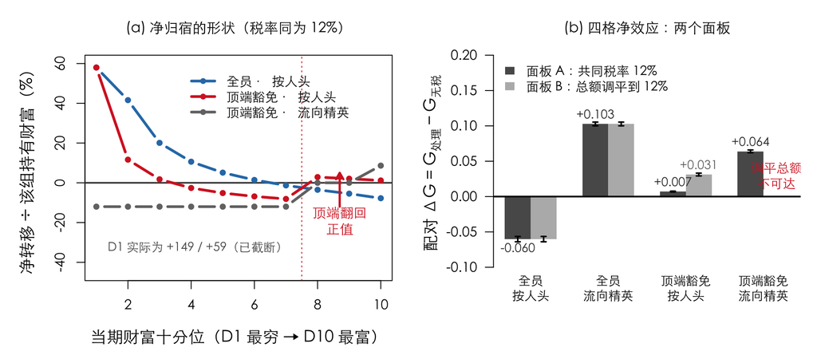

```r
tax2 <- function(tau = 0.12, exempt = 0, flow = "percapita", kind = "rank",
                 N = 1200, rounds = 400, burn = 100, seed = 1){
  set.seed(seed); w <- rep(1, N); half <- N/2; E <- rep(FALSE, N); D <- 10
  pay <- rec <- wt <- numeric(D); rev_tot <- 0; occ <- numeric(0); nE <- round(exempt*N)
  for (r in 1:rounds){
    if (r == burn && exempt > 0){                       # burn-in 到基线后再定身份
      if (kind == "perm")  E[order(w, decreasing = TRUE)[1:nE]] <- TRUE
      if (kind == "caste") E[sample.int(N, nE)] <- TRUE
    }
    if (r >= burn && tau > 0){
      if (kind == "rank" && exempt > 0){ E[] <- FALSE
        E[order(w, decreasing = TRUE)[1:nE]] <- TRUE }  # 每轮按当期财富重选
      el <- order(w, decreasing = TRUE)[1:round(0.10*N)]  # 精英受益组：独立于 E
      d  <- ceiling(rank(w, ties.method = "first")/N*D)
      tx <- ifelse(E, 0, tau)*w; rv <- sum(tx); rev_tot <- rev_tot + rv
      tr <- if (flow == "percapita") rep(rv/N, N) else { v <- numeric(N); v[el] <- rv/length(el); v }
      pay <- pay + tapply(tx, factor(d, 1:D), sum)
      rec <- rec + tapply(tr, factor(d, 1:D), sum)
      wt  <- wt  + tapply(w,  factor(d, 1:D), sum)
      w <- w - tx + tr
      if (any(E)) occ <- c(occ, mean(rank(w)[E] > N*0.9))  # 豁免组占据顶端 10% 的比例
    }
    idx <- sample.int(N); i <- idx[1:half]; j <- idx[(half+1):N]
    p <- w[i] + w[j]; e <- runif(half); w[i] <- e*p; w[j] <- (1-e)*p
  }
  list(gini = gini(w), rev = rev_tot/(rounds-burn+1)/N, inc = 100*(rec-pay)/wt, occ = occ)
}
CAL <- 1:3; SEEDS <- 1:8; TARGET <- 0.12                  # 校准与报告用不同种子
mrev <- function(t, ex, fl, sd) mean(unlist(parallel::mclapply(sd, function(s)
          tax2(tau = t, exempt = ex, flow = fl, seed = s)$rev,
          mc.cores = min(.PAR, length(sd)))))
## 逐格校准：扫描 [0,1] 验证可达与唯一，再求根；不可达则标 NA
fit <- function(ex, fl){
  if (ex == 0) return(TARGET)                             # 全员征收时收入恰为 tau（解析）
  gr <- seq(0.02, 0.98, length.out = 9)
  ## 网格的 9x3 次调用铺平成一层并行，避免 mclapply 嵌套
  gs <- expand.grid(s = CAL, t = gr)
  rv <- unlist(parallel::mclapply(seq_len(nrow(gs)), function(k)
          tax2(tau = gs$t[k], exempt = ex, flow = fl, seed = gs$s[k])$rev, mc.cores = .PAR))
  rr <- apply(matrix(rv, nrow = length(CAL)), 2, mean)
  cross <- which(diff(sign(rr - TARGET)) != 0)
  if (length(cross) != 1) return(NA_real_)                # 不可达或非唯一
  uniroot(function(t) mrev(t, ex, fl, CAL) - TARGET, gr[c(cross, cross+1)])$root
}
cells <- expand.grid(exempt = c(0, 0.30), flow = c("percapita", "elite"),
                     stringsAsFactors = FALSE)
cells$tauB <- mapply(fit, cells$exempt, cells$flow)
G0 <- unlist(parallel::mclapply(SEEDS, function(s) tax2(tau = 0, seed = s)$gini, mc.cores = .PAR))
run_cells <- function(tv) t(mapply(function(ex, fl, tt){
  if (is.na(tt)) return(c(dG = NA, lo = NA, hi = NA, rev = NA))
  o <- parallel::mclapply(SEEDS, function(s) tax2(tau = tt, exempt = ex, flow = fl, seed = s),
                          mc.cores = .PAR)
  d <- sapply(o, `[[`, "gini") - G0; n <- length(d)
  c(dG = mean(d), lo = mean(d) - qt(.975, n-1)*sd(d)/sqrt(n),
    hi = mean(d) + qt(.975, n-1)*sd(d)/sqrt(n), rev = mean(sapply(o, `[[`, "rev")))
}, cells$exempt, cells$flow, tv))
B <- run_cells(cells$tauB)                                # 面板 B：逐格总额调平到 12%
A <- run_cells(rep(TARGET, 4))                            # 面板 A：四格共同税率 12%
## cells 由 expand.grid(exempt=c(0,0.30), flow=c("percapita","elite")) 生成；
## expand.grid 第一个因子变化最快，行序是：
## 1 全员/按人头  2 顶端豁免/按人头  3 全员/流向精英  4 顶端豁免/流向精英
## （与下面 ord <- c(1,3,2,4) 那组标签一致）
## 总图那条"非豁免者纳税 + 支出流向精英"= 顶端豁免 且 流向精英 = 第 4 行。
stopifnot(nrow(cells) == 4, cells$exempt[4] == 0.30, cells$flow[4] == "elite",
          cells$exempt[2] == 0.30, cells$flow[2] == "percapita")
reg("cov_elite",  mean(G0) + A[4, "dG"], "derived", "§6.3.4 tax_coverage",
    "无税基线 mean(G0) 加面板 A 实测的配对效应 dG")
reg("cov_exempt", mean(G0) + A[2, "dG"], "derived", "§6.3.4 tax_coverage", "同上")
## 身份定义的三种版本（同一豁免比例、同一税率），检验"豁免是否持续追踪财富"
KIND <- sapply(c("rank","perm","caste"), function(k){
  o <- parallel::mclapply(SEEDS, function(s) tax2(tau = TARGET, exempt = 0.30, kind = k, seed = s),
                          mc.cores = .PAR)
  c(dG = mean(sapply(o, `[[`, "gini") - G0),
    occ0 = mean(sapply(o, function(x) x$occ[1])),
    occ1 = mean(sapply(o, function(x) x$occ[length(x$occ)])))
})
## 净归宿三条线一律用共同税率 12%（面板 A），避免税率差混入形状
INC <- list(tax2(TARGET, 0,    "percapita")$inc,
            tax2(TARGET, 0.30, "percapita")$inc,
            tax2(TARGET, 0.30, "elite")$inc)
UP <- "#D62728"; DN <- "#2C7BB6"; GY <- "gray45"; COL <- c(DN, UP, GY)
par(mfrow = c(1, 2), mar = c(4.8, 5.2, 3.4, 1.0), cex.lab = 1.2, cex.main = 1.05, family = "cjk")
plot(NA, xlim = c(1, 10), ylim = c(-45, 60), xlab = "当期财富十分位（D1 最穷 → D10 最富）",
     ylab = "净转移 ÷ 该组持有财富（%）", main = "(a) 净归宿的形状（税率同为 12%）")
abline(h = 0, lwd = 2, col = "gray30"); abline(v = 7.5, lty = 3, col = UP)
for (k in 1:3) lines(1:10, pmin(INC[[k]], 58), col = COL[k], lwd = 3.2, type = "b", pch = 16)
text(1.1, -33, sprintf("D1 实际为 %+.0f / %+.0f（已截断）", INC[[1]][1], INC[[2]][1]),
     col = "gray35", cex = 0.9, pos = 4)
arrows(8.7, -12, 8.7, 5, length = 0.09, lwd = 2.6, col = UP)
text(8.7, -19, "顶端翻回\n正值", col = UP, cex = 1.0)
legend(3.9, 59, c("全员 · 按人头", "顶端豁免 · 按人头", "顶端豁免 · 流向精英"),
       col = COL, lwd = 3.2, pch = 16, bty = "n", cex = 0.95)

ord <- c(1, 3, 2, 4)
lab <- c("全员\n按人头", "全员\n流向精英", "顶端豁免\n按人头", "顶端豁免\n流向精英")
dA <- A[ord, "dG"]; dB <- B[ord, "dG"]
par(mar = c(5.4, 5.2, 3.4, 1.0))
b <- barplot(rbind(dA, dB), beside = TRUE, names.arg = lab, border = NA, las = 1,
     col = c("gray35", "gray72"), ylim = c(-0.105, 0.20), cex.names = 0.92,
     ylab = expression(paste("配对 ", Delta, "G = ", G[处理] - G[无税])),
     main = "(b) 四格净效应：两个面板")
arrows(b[1,], A[ord,"lo"], b[1,], A[ord,"hi"], angle=90, code=3, length=0.03, lwd=1.8)
arrows(b[2,], B[ord,"lo"], b[2,], B[ord,"hi"], angle=90, code=3, length=0.03, lwd=1.8)
abline(h = 0, lwd = 2)
text(b[1,], dA + ifelse(dA > 0, 0.014, -0.012), sprintf("%+.3f", dA), cex = 0.9, col = "gray20")
near <- !is.na(dB) & abs(dB - dA) < 0.01                 # 两面板几乎重合时，只标一次
k <- !is.na(dB) & !near
text(b[2,][k], dB[k] + ifelse(dB[k] > 0, 0.014, -0.012),
     sprintf("%+.3f", dB[k]), cex = 0.9, col = "gray45")
text(b[2,4], 0.03, "调平总额\n不可达", col = UP, cex = 0.95, font = 2)
legend("topleft", c("面板 A：共同税率 12%", "面板 B：总额调平到 12%"),
       fill = c("gray35", "gray72"), border = NA, bty = "n", cex = 0.95)
```

先看校准与可行性。无税基线实测 0.5002 ± 0.0101（8 个种子，校准与报告用不同种子）。顶端豁免 30% 后，同样 12% 的税率只能收到 4.0% ——顶端不缴，收入立刻掉到三分之一。要把总额补回 12%，税率必须抬到 39.4%。又一次“税率更高、再分配更少”。

而第四格根本不可达。当顶端既不纳税、又是支出的唯一受益者，税基被政策自己吃掉：即使把非豁免者的财富全部没收（$\tau\to1$），也收不到 12%——扫描区间内的上限只有约 10%。这一格在面板 B 里标为不可行，而这个不可行本身就是结果，下一小节那条算术 $r=T/B$ 讲的正是它。

四格读法（面板 A，税率同为 12%）：

- 全员 + 按人头返还：$\Delta G$ = -0.060。教科书里的再分配。
- 全员 + 流向精英：+0.103。这一格是定义上的向上转移，不是发现——对所有人征税、只发给最富的 10%，当然推高不平等。它的作用是隔离支出效应。
- 顶端豁免 + 按人头返还：+0.007，置信区间 [+0.006, +0.008]。支出方式完全没变，税率也没变，变的只有“顶端不在税基里”——符号翻了。但要老实说：幅度很小。调平总额之后（面板 B）它是 +0.031，因为补足收入所需的高税率又额外压在了中间层身上。
- 顶端豁免 + 流向精英：+0.064。

> 本文能证的只有存在性：存在参数区间，使得仅仅因为顶端不在税基里，同一个方向的支出安排从压低不平等变成推高。证不了必然，也证不了幅度可观——同一税率下那个 +0.007 是一个可辨但很小的数。

左图解释了符号为什么会翻。它画的是**净归宿**——每个财富十分位拿到的净转移，除以它持有的财富，三条线税率同为 12%。蓝线（全员税基）单调下降：越穷拿得越多，越富付得越多，这是再分配该有的形状。红线（顶端豁免）在中段掉得更深（D7 到 -8%），然后在豁免线处翻回正值——顶端三个十分位变成净受益者。

> 压在中间，顶端净得。这就是“顶端不在税基里”在分布上的确切样子；它和第 6.3.3 节那句“现实里的有效税率沿财富分布不是单调递增”是同一件事——这里给出了一个量出来的实例。

豁免挂在什么上，比豁免多大更要紧。上面的豁免是**按当期财富位次**每轮重算的（谁这轮在顶端谁就躲得掉）。换成**永久身份**（burn-in 之后冻结一批人，像世袭爵位），以及**随机种姓**（与财富无关地随机指定）作对照，同一税率、同一豁免比例下：

| 豁免挂在什么上 | ΔG | 刚冻结时占据顶端 10% 的比例 | 跑到末尾时 |
| --- | --- | --- | --- |
| 当期财富位次（每轮重算） | +0.007 | 0.33 | 0.33 |
| 永久身份（burn-in 后冻结） | -0.041 | 0.33 | 0.13 |
| 随机种姓（与财富无关） | -0.037 | 0.13 | 0.15 |

只有追踪当期财富的那一版翻了符号，另外两版仍然压低不平等。原因在后两列：永久身份组刚冻结时占据顶端十分位的比例是 0.33，跑到末尾只剩 0.13——已经和随机种姓组（0.15）分不出来了。名单没变，但它不再对应顶端。

所以现实中的身份豁免之所以能改变分布的方向，靠的不是那张名单本身，而是身份与财富之间的长期绑定。绑定一松，同一张豁免名单就退化成一次随机指定。（本文只做了“完全追踪”与“完全冻结”两个极端，中间地带没有扫过，而符号恰恰对这条绑定的强弱敏感：存在性已证，形状未知。）

#### 6.3.4.1 四个史实，四种“不在税基里”

| 案例 | 税基与单位 | 期间与人群 | 谁不在税基里（属哪一类） | 支出去向 | 这条证据量的是什么 |
| --- | --- | --- | --- | --- | --- |
| 波旁法国：taille personnelle（pays d'élection） | 按户征收的直接税，年度摊派 | 旧制度时期；第三等级 | 教士与贵族——法定范围 | 宫廷、军队、官僚（未在本文量化） | 法定归宿，不是财富基尼 |
| 清代漕粮（Stipend Rice） | 实物粮；法定定额 400 万石送京 | 清代，八省漕区；纳粮村户 | 村内「有势力的户」实际避掉自己那份——逃避税 + 行政能力 | 定额入京；超收由包税的村绅留存 | 抽取总量与中间人留存，不是财富基尼 |
| 当代中国 | 个人所得税；房产税 | 1997 起（股票）／2011 起（房产税试点）；个人 | 上市公司股票转让所得「暂免」——法定范围；房产税未立法 | 一般公共预算（未在本文量化） | 法定税基范围，不是任何基尼 |
| 当代美国 | 联邦所得税 | 现行；ProPublica 覆盖 2014–2018 的最富 25 人 | 未实现增值——实现时点；质押借款不构成应税事件 | 联邦一般收入（未在本文量化） | 个人有效税率（特殊口径），不是财富基尼 |

**这张表的出处状况（可跳过）**

先交代这张表的出处状况：清代漕粮一行的数字与引文出自 Deng (2021)；当代美国一行出自 Eisinger et al. (2021)；当代中国一行的两条制度事实按财税文号引（财税字〔1998〕61 号、财税〔2009〕167 号）。波旁法国一行本文没有给出文献出处——它陈述的是 taille personnelle 的法定征收范围这一制度事实，不含任何数字，也不参与后文的任何计算；出处待补。

四行里清代漕粮这一条最完整，因为它的数字是可查的。法定定额是 400 万石送到北京，“只要这 400 万石送到，就没人再问”；征收包给村绅，而包税的实收额在定义上是开放式的——最终实际征到的至少多出 1000 万石，总实收因此至少是法定定额的 3.5 倍，即超收至少为定额的 2.5 倍。多出来的部分从未到过北京，由地方绅户作为收入留下。村内的负担也不均：“米粮的份额不成比例地落在普通村民身上，有势力的户则尽力躲掉自己那份” (Deng 2021)。1830 年代的一份奏报里，村绅年均获利 100 两白银——相当于北京一位部级官员的年俸；极端情形下，一粒粮食都没经手的村绅拿到几千两 (Deng 2021)。

这一条给出的论点是：国家拿到 400 万石，社会付出至少 1400 万石，差额是一笔纯粹的向上转移。

**这层解释是推断，不是引文（可跳过）**

把它读成“征税能力不足”或“国家看不见实收”，超出了引文所述的事实——开放式超收与中间人留存本身并不证明行政无能，也可能是默许的分成安排。本文只把制度事实当证据，这层解释标为推断。

但必须连作者自己的反向结论一起引。Deng 这篇文章的主旨恰恰是帝制中国的税负超低：把超收全部算进去，人均年负担仍只相当于约 25 克粮食，他因此判断绅户的额外抽租“确实抬高了直接税负，但幅度有限”，并明说“如果绝对税负本来就轻，税负不平等就没那么要紧” (Deng 2021)。机制有据，量级由作者判定为有限——两句必须一起读。

当代那两行只陈述可核的制度事实，不做评价：

- 中国：个人转让上市公司股票所得，自 1997 年 1 月 1 日起“暂免”征收个人所得税（财税字〔1998〕61 号）；限售股自 2010 年起纳入征收（财税〔2009〕167 号）。“暂免”这个“暂”字，自 1997 年沿用至今已 29 年。房产税方面，2011 年沪、渝试点，2021 年全国人大常委会授权在“部分地区”开展试点，2022 年缓行，2023 年起未列入十四届全国人大常委会立法规划。
- 美国：以增值资产质押借款（SBLOC）不构成应税事件，因为借来的钱不是所得；持有至死亡时，继承人的计税基础按当时市值重置（step-up in basis），生前累积的增值在税上归零。ProPublica 据泄露的报税数据算出，最富的 25 人在 2014–2018 年间财富增长 4010 亿美元，缴纳的联邦所得税相当于其中的 3.4% (Eisinger et al. 2021)。

**SBLOC 这条路的成本（可跳过）**

这条路并非没有成本：质押要付利息、市价下跌可能被强制平仓、本金终须偿还，遗产税也可能适用；本文未量化这些成本。

#### 6.3.4.2 一条算术：定额包税为什么会自己收紧

清代那个定额还藏着一个更硬的东西，而它不需要模拟，一行算术就够：

$$r_t \;=\; \frac{T}{B_t}$$

$T$ 是法定定额（分子，固定），$B_t$ 是还在税基里的财富（分母）。豁免每扩大一分，分母就小一分，于是剩下的人被迫承担更高的税率——而税率一高，逃出税基的动机又更强。

边界是清楚的：$r_t = 1$ 意味着把非豁免者的财富全部没收，仍然勉强可行；真正的不可行始于 $r_t > 1$——那时无论怎么征都凑不齐定额。

两句必须说明白：这是一个构造出来的情景，不是内生发现。只要设定“豁免只增不减”，税基萎缩就近乎同义反复。它的价值不在于预言，而在于把“定额”这个制度特征的后果写成了一个可以直接看的分式：当国家把收入目标定死、而税基可以流失时，负担会自动向留在税基里的人集中。这也不是第 5 章那个“交换冻结”——那里停下来的是交换本身，这里停下来的只是国家的收入，交换照常进行。

### 6.3.5 四骑士：历史上真正压低过不平等的东西

第 2.4 节提过 Scheidel 的结论：翻遍史料，显著压低过不平等的只有四种暴力冲击——大规模动员战争、革命、国家崩溃、瘟疫 (Scheidel 2017)。税收在他那份名单上排不上号。这个论断值得放进模型里看一眼，因为四骑士里有两样是这台机器能测的。

```r
N <- 4000; half <- N/2
step <- function(w){ idx <- sample.int(N); i <- idx[1:half]; j <- idx[(half+1):N]
  pooled <- w[i] + w[j]; e <- runif(half); w[i] <- e*pooled; w[j] <- (1-e)*pooled; w }
set.seed(5); w <- rep(1, N); for (r in 1:600) w <- step(w)      # 先跑到平衡
g0 <- gini(w)

## 骑士一、二：战争 / 革命 —— 没收顶端 10% 超出部分，按人头返还
w1 <- w; cut <- quantile(w1, 0.9); take <- pmax(w1 - cut, 0)
w1 <- w1 - take + sum(take)/N
g_shock <- gini(w1)
gs <- numeric(400); for (r in 1:400){ w1 <- step(w1); gs[r] <- gini(w1) }
reg("confiscate", g_shock, "point", "§6.3.5 horsemen", "一次性没收顶端 10% 超出部分并按人头返还")

## 骑士四：瘟疫 —— 随机减员 30%。随机抽样只在**期望**上不改变分布形状，
## 单次实现必然不等于 g0，所以报重复实验的均值与区间，不报单次。
set.seed(6); PLG_R <- 200
plg <- replicate(PLG_R, gini(w[sample(N, round(0.7*N))]))
PLG <- list(m = mean(plg), lo = unname(quantile(plg, .025)),
            hi = unname(quantile(plg, .975)), R = PLG_R)
g_plague <- PLG$m
reg("plague", PLG$m, "stochastic-neutral", "§6.3.5 horsemen",
    sprintf("对同一个平衡态实现做 %d 次随机抽稀的均值；区间 [%.4f, %.4f] 覆盖冲击前的 %.4f",
            PLG$R, PLG$lo, PLG$hi, g0), neutral = (PLG$lo <= g0 && g0 <= PLG$hi))
c(`冲击前` = g0, `没收后` = g_shock, `10 轮后` = gs[10],
  `50 轮后` = gs[50], `400 轮后` = gs[400], `随机减员 30%` = g_plague)
```

```
##       冲击前       没收后      10 轮后      50 轮后     400 轮后 随机减员 30%
##    0.5007595    0.4001254    0.4904408    0.5063188    0.5033394    0.5008006
```

| 骑士 | 模型里对应什么 | 效果 | 能维持吗 |
| --- | --- | --- | --- |
| 战争 / 革命 | 一次性没收顶端，按人头返还 | 基尼 0.50 → 0.40 | 不能：50 轮后已回到 0.51 |
| 瘟疫 | 随机减员 30% | 基尼 0.50 → 0.501（200 次重复的均值） | 本模型测不出（见下） |

三条结论，一条比一条要紧。

第一，冲击确实能砸下去，但基线会自己长回来——而且快得惊人。没收顶端 10% 的超出部分再平分，基尼从 0.50 掉到 0.40；然后什么也不用做，10 轮后已经回到 0.49，50 轮后 0.51，完全复原。这不是模型偷懒——它正是“最大熵态”的含义：那个分布是随机搅拌的不动点，你把它推开，它自己走回去。

> 于是 Scheidel 那条史学结论在这里得到了一个机制解释：冲击型的平等化必然是暂时的，因为它改变的是状态，不是规则。而规则没变，状态就会漂回去。

这也反过来给税收正名了。税收在四骑士名单上排不上号，是因为它单次强度小；但它是持续施加的——在模型里，$\tau$ 是每一轮都在拧的旋钮，而没收是拧一次就松手。要对抗一个会自我恢复的基线，持续的弱力胜过一次性的强力。

第二，国家崩溃这一条本文没有建模，但值得点出它为什么是另一类。战争、革命、瘟疫都是改变状态——把财富砸掉或把人减掉，而基线会把状态拉回去。国家崩溃改的是规则：财产权失效，抽取机制本身停摆。按上一条的逻辑，改变规则的冲击才可能持久的那个。

第三，瘟疫这一条本模型测不出来，得说清楚。随机减员 30%，基尼几乎不动：0.5008，区间 [0.4954, 0.5064]，覆盖了冲击前的 0.5008——因为随机抽样不改变分布的形状。（口径要说准：这 200 次重复是对同一个平衡态实现反复抽稀，所以区间里不含“重跑平衡态”那一层不确定性，它量的是抽稀本身。）但 Scheidel 说的瘟疫机制根本不在这里：黑死病压低不平等，靠的是劳动力骤减 → 工资相对地租上涨，那是要素价格的变化。本模型里没有劳动、没有土地、没有价格，所以这一条不是被证伪，是超出量程。列在这里是为了标明边界。

最后把第 2.5 节留的那笔账结掉。那里记下一个对照：Scheidel 从史料得出“和平的再分配从未大幅压低过不平等”，而本文从模型会得出一个更麻烦的版本——再分配连方向都不是给定的。两条路互相独立，问的是它们会不会指向同一件事。

会，而且模型这一侧给史料那一侧补上了一个候选机制。

Scheidel 报告的是一个结果：翻遍史料，和平手段没怎么奏效过。第 6.3.4 节量的是为什么可能没奏效——再分配的符号取决于两件事，税基覆盖谁、支出流向谁，而这两个旋钮拧到某些位置时，“再分配”会把基尼推高（总图上“非豁免者纳税 + 支出流向精英”那一行，从 0.5 推到 0.56——方向朝上）。

这一段只能说到这里为止。模型给的是一个候选解释，不是对 Scheidel 的检验：本文没有量过任何史料，四个案例只是制度事实的举例，不构成样本。要真的检验它，需要的是历史税基与支出归宿的系统数据，那是另一门手艺。

## 6.4 富人的投资：错误、运气与再分配

“不怕富二代消费，就怕富二代投资。”这句在中文互联网上流传很广的话，抓住了一个真实的机械差别：消费是加性的，投资是乘性的。

一个人每年花掉一笔固定的钱，这笔钱相对于他的总财富会越来越小；投资动的是本金的一个比例，一次判断错误可以在一个回合里拿走一大块。第 2 章那座岛上的加性交换停在 0.5，第 4 章的乘性下注一路走向 1；把同一个区分放到一个人的一生里，就是这句话的算术部分。消费再奢侈，也很难把一笔巨大的财富花完；投资不需要奢侈，只需要一次集中的下注。

先把两件事分开。第一，作为持续起作用的规则，投资回报率随财富上升：钱越多，越能持有高回报资产、越进得去高回报市场，平均回报越高。这是拉开差距的力量；本文第 6.1.3 节的资本回报，量的就是这一类力量。第二，投资错误是一次冲击：它可以把某个人、某一代人打下去，可能削掉顶端，却不会把底部抬起来。前者是平均，后者是局部；前者是规则，后者是事件。流行语把第二件事说成了第一件事，于是把“富二代守不住”读成了“投资会均贫富”。下面先看文献，再把这笔账放进模型。

### 6.4.1 富人是不是更不会投资

家庭金融这一支的答案是否定的，至少不是普遍成立。Calvet、Campbell 与 Sodini 用瑞典全人口的资产负债表看组合错误：分散不足和“不参与风险资产”确实有代价，但金融素养越高，投资越有效率；同时他们也更敢冒险，所以错误的福利成本不一定更小 (Calvet et al. 2007)。Barber 与 Odean 的经典结果更窄：交易越频繁，净回报越低，毛回报却差不多——差的是成本和税，不是选股能力 (Barber and Odean 2000)。把这两条放在一起，得到的是一个“谁更会投资”的连续谱，而不是“富人更笨”的标签。

财富与回报的关系更直接。Bach、Calvet 与 Sodini 用瑞典的行政面板算家庭净财富的期望回报：回报随净财富上升，最顶端那一小撮超过无风险利率的部分，大致就是股权溢价；他们还估计，财富回报解释了历史上顶层财富份额上升的大部分 (Bach et al. 2020)。Fagereng、Guiso、Malacrino 与 Pistaferri 用挪威的全国税务面板得到同向的结果：从净值分布第 10 到第 90 百分位，回报率高出 18 个百分点（税后 10 个百分点），而且回报有持续性、跨代相关 (Fagereng et al. 2020)。如果这两篇是对的，那么“投资”在平均意义上不是富人的漏财渠道，而是他们的聚财渠道。

但“平均”恰好会把题目问的那一小撮人盖住。真正像“富二代”的故事，不是富人在二级市场上选股，而是继承了一家公司的控制权，然后自己来经营。公司金融这一支有比较硬的因果证据。Pérez-González 用 CEO 交接的数据比较“传给亲属”和“传给外部人”：传给亲属的公司，资产营业利润率和市净率都更差；没上过精英本科的家族 CEO 尤其差 (Pérez-González 2006)。Bennedsen、Nielsen、Pérez-González 与 Wolfenzon 用丹麦的数据，拿“第一个孩子是男是女”做工具变量——男孩更可能把控制权传给家族——估计家族接班让资产营业利润率至少掉 4 个百分点 (Bennedsen et al. 2007)。这不是“投资组合没分散”的那种错误，是把一整家公司的资本配置交给了一个没有经过市场筛选的人。

横财这一支的证据更接近“靠运气拿到资产”。Hankins、Hoekstra 与 Skiba 比较佛罗里达州彩票的大奖得主和小奖得主：大额奖金并没有让破产消失，只是把它推迟；后来破产的大奖得主，净资产和无担保债务与小奖得主差不多 (Hankins et al. 2011)。Andersen、Mukherjee 与 Nielsen 用父母突然去世带来的意外遗产做识别：赌注变大确实会减少投资错误，但效果在经济上很小，错误不会因为钱多就自动消失 (Andersen et al. 2021)。这两篇合起来说的是：横财买不到与财富匹配的投资能力。

所以，文献给出的不是一句话的判决，而是一张分层的图：平均而言，财富与投资回报正相关，富人不是更差的投资者；但在“继承控制权”和“突然拿到一笔钱”这两个局部，确实存在能力与财富不匹配的通道。前一条是平均，后一条是方差。那句流行语抓的是后一条，却把它说成了前一条。

### 6.4.2 把“错误”放进同一台机器

```r
## 第 5 章那台引擎的一次实现：σ=0.6，N=1200，500 轮。
## 这一节只做一次性的对照实验，不跑动力学；初始分布固定，五种规则各自作用一次。
inv_sig <- 0.6; inv_N <- 1200; inv_burn <- 500; inv_seed <- 1
inv_loss <- 0.10
reg("inv_sig", inv_sig, "analytic", "§6.4 invest_setup", "对照实验：背景 σ")
reg("inv_N", inv_N, "analytic", "§6.4 invest_setup", "对照实验：人口")
reg("inv_burn", inv_burn, "analytic", "§6.4 invest_setup", "对照实验：预热轮数")
reg("inv_seed", inv_seed, "analytic", "§6.4 invest_setup", "对照实验：种子")
reg("inv_loss", inv_loss, "analytic", "§6.4 invest_setup", "一次性冲击占总财富的比例")

## 本节的 top-p 份额；只在这里定义，避免和别的 chunk 的短名冲突。
inv_topshare <- function(w, p = 0.01){
  n <- length(w); sum(sort(w, decreasing = TRUE)[1:round(n*p)])/sum(w)
}

inv_w0 <- one_w(inv_sig, inv_seed, inv_N, inv_burn)
inv_L <- inv_loss*sum(inv_w0)
inv_top1_0 <- order(inv_w0, decreasing = TRUE)[1:round(0.01*inv_N)]
inv_top10_0 <- order(inv_w0, decreasing = TRUE)[1:round(0.10*inv_N)]
inv_g0 <- gini(inv_w0)
inv_t1_0 <- inv_topshare(inv_w0, 0.01)
reg("inv_g0", inv_g0, "point", "§6.4 invest_setup", "初始基尼（σ=0.6 的一次实现）")
reg("inv_top1_0", inv_t1_0, "point", "§6.4 invest_setup", "初始前 1% 占有")
```

```r
## 五种落地方式。前四条都让总损失等于 inv_loss×总财富；第五条是算术边界。
inv_arm <- function(kind){
  w <- inv_w0
  if (kind == "tax")  return((1 - inv_loss)*w + inv_loss*mean(w))
  if (kind == "unif") return((1 - inv_loss)*w)
  idx <- switch(kind,
    prop10 = order(w, decreasing = TRUE)[1:round(0.10*inv_N)],
    prop1  = order(w, decreasing = TRUE)[1:round(0.01*inv_N)])
  w[idx] <- w[idx] - (inv_L/sum(w[idx]))*w[idx]
  w
}
inv_tax <- inv_arm("tax"); inv_unif <- inv_arm("unif")
inv_prop10 <- inv_arm("prop10"); inv_prop1 <- inv_arm("prop1")

## 位次留存：初始的前 1%／前 10% 有多少还留在同一档
inv_keep <- function(w, idx0, p){
  idx <- order(w, decreasing = TRUE)[1:round(p*inv_N)]
  mean(idx %in% idx0)
}
inv_tab <- function(w) c(
  gini = gini(w), top1 = inv_topshare(w, 0.01),
  keep1 = inv_keep(w, inv_top1_0, 0.01),
  keep10 = inv_keep(w, inv_top10_0, 0.10),
  total = sum(w)/sum(inv_w0))
inv_A <- rbind(initial = inv_tab(inv_w0), tax = inv_tab(inv_tax),
               unif = inv_tab(inv_unif), prop10 = inv_tab(inv_prop10),
               prop1 = inv_tab(inv_prop1))

## 解析自检：税是仿射变换，基尼精确乘 (1−τ)；统一损失是等比缩放，基尼精确不变。
stopifnot(abs(inv_A["tax","gini"] - (1 - inv_loss)*inv_g0) < 1e-12,
          abs(inv_A["unif","gini"] - inv_g0) < 1e-12,
          abs(inv_A["tax","total"] - 1) < 1e-12,
          abs(inv_A["unif","total"] - (1 - inv_loss)) < 1e-12,
          abs(inv_A["tax","keep1"] - 1) < 1e-12,
          abs(inv_A["unif","keep1"] - 1) < 1e-12,
          inv_A["prop1","keep1"] < 1, inv_A["prop10","keep10"] < 1)

reg("inv_tax_g", inv_A["tax","gini"], "derived", "§6.4 invest_arms", "10% 财富税 + 人头返还后的基尼")
reg("inv_tax_top1", inv_A["tax","top1"], "derived", "§6.4 invest_arms", "同上：前 1% 占有")
reg("inv_tax_keep1", inv_A["tax","keep1"], "derived", "§6.4 invest_arms", "同上：前 1% 留存率")
reg("inv_unif_g", inv_A["unif","gini"], "analytic", "§6.4 invest_arms", "统一 10% 损失后的基尼（尺度不变）")
reg("inv_unif_top1", inv_A["unif","top1"], "analytic", "§6.4 invest_arms", "同上：前 1% 占有")
reg("inv_unif_keep1", inv_A["unif","keep1"], "analytic", "§6.4 invest_arms", "同上：前 1% 留存率")
reg("inv_prop10_g", inv_A["prop10","gini"], "derived", "§6.4 invest_arms", "前 10% 承担 10% 损失后的基尼")
reg("inv_prop10_top1", inv_A["prop10","top1"], "derived", "§6.4 invest_arms", "同上：前 1% 占有")
reg("inv_prop10_keep10", inv_A["prop10","keep10"], "derived", "§6.4 invest_arms", "同上：前 10% 留存率")
reg("inv_prop10_keep1", inv_A["prop10","keep1"], "derived", "§6.4 invest_arms", "同上：前 1% 留存率")
reg("inv_prop1_g", inv_A["prop1","gini"], "derived", "§6.4 invest_arms", "前 1% 承担 10% 损失后的基尼")
reg("inv_prop1_top1", inv_A["prop1","top1"], "derived", "§6.4 invest_arms", "同上：前 1% 占有")
reg("inv_prop1_keep1", inv_A["prop1","keep1"], "derived", "§6.4 invest_arms", "同上：前 1% 留存率")
reg("inv_prop1_keep10", inv_A["prop1","keep10"], "derived", "§6.4 invest_arms", "同上：前 10% 留存率")
reg("inv_prop10_loss", inv_L/sum(inv_w0[inv_top10_0]), "derived", "§6.4 invest_arms", "前 10% 每人的损失比例")
reg("inv_prop1_loss", inv_L/sum(inv_w0[inv_top1_0]), "derived", "§6.4 invest_arms", "前 1% 每人的损失比例")

## 底部一半：全部财富也不够吸收这笔损失；全部抹掉只是一个上界。
inv_bot50 <- order(inv_w0)[1:round(0.50*inv_N)]
inv_b50_share <- sum(inv_w0[inv_bot50])/sum(inv_w0)
inv_wipe <- inv_w0; inv_wipe[inv_bot50] <- 0
inv_wipe_g <- gini(inv_wipe); inv_wipe_t1 <- inv_topshare(inv_wipe, 0.01)
reg("inv_bottom50_share", inv_b50_share, "derived", "§6.4 invest_arms", "底部 50% 占总财富的份额")
reg("inv_wipe_g", inv_wipe_g, "derived", "§6.4 invest_arms", "底部 50% 全部清零后的基尼")
reg("inv_wipe_top1", inv_wipe_t1, "derived", "§6.4 invest_arms", "同上：前 1% 占有")
stopifnot(inv_wipe_g > inv_g0, inv_b50_share < inv_loss)
```

把这条通道放进模型，不需要新机器。第 5 章那台引擎已经能生出一个集中分布；这一节只问一个问题：同样一笔相当于总财富 10% 的钱，让税来征、让投资错误来销毁、让不同的人来承担，结果差在哪？

先做一个对照实验。取第 5 章 σ=0.6 的一次实现（N = 1200，500 轮；基尼 0.678，前 1% 占有 0.183），然后把总财富的 10% 作为一笔冲击，分五种方式落地：

1. 税：按财富比例征 10%，再按人头等额返还。总财富不变。
2. 统一损失：每个人损失 10%。总财富少 10%，分布形状不变。
3. 前 10% 犯错：损失全部由前 10% 承担，每人损失 18.4%。
4. 前 1% 犯错：损失全部由前 1% 承担，每人损失 54.6%。
5. 底部一半：他们的全部财富只有总财富的 7.9%，凑不出这笔损失；把他们的财富全部抹掉，总损失也只有 7.9%。

第 1 条是税，第 2 到 4 条是投资错误，区别只在“谁承担”。第 5 条不是一种可行的投资错误，而是算术上的边界：底部一半人根本没有足够的财富来吸收一笔宏观损失。先看前四条。

这是一次说明性的对照，不是对现实里投资错误频率或幅度的估计。参数只有一个目的：把“谁承担”这一维度单独拎出来，其余全部按住不动。

同样一笔 10% 的财富：谁承担

| 规则 | 损失怎么分配 | 总财富 | 基尼 | 前 1% 占有 | 前 1% 留存 | 前 10% 留存 |
| --- | --- | --- | --- | --- | --- | --- |
| 初始分布 | — | 100% | 0.678 | 18.3% | 1.000 | 1.000 |
| 税 10% | 按财富征，按人头返还 | 100% | 0.610 | 16.6% | 1.000 | 1.000 |
| 统一损失 10% | 每人损失 10% | 90% | 0.678 | 18.3% | 1.000 | 1.000 |
| 前 10% 犯错 | 每人损失 18.4% | 90% | 0.649 | 16.6% | 1.000 | 0.875 |
| 前 1% 犯错 | 每人损失 54.6% | 90% | 0.644 | 11.5% | 0.333 | 1.000 |

上表把五种方式摊开。先看税和统一损失这两行，它们是两个精确的锚点。税让基尼从 0.678 降到 0.610，正好是初始值乘 0.90；因为 $w \mapsto (1-\tau)w + \tau\mu$ 是仿射变换，Lorenz 曲线变成 $(1-\tau)L + \tau p$，曲线与对角线的面积也乘 $(1-\tau)$。位次一个没动：前 1% 留存率 1.000。统一损失让基尼停在 0.678，和初始值一模一样；因为 $w \mapsto (1-\ell)w$ 在绝对财富上只是等比例缩小，而 Lorenz 曲线按各自总量归一，形状原封不动，基尼是尺度不变量。位次也没动。

真正有意思的是后两行。让前 10% 承担全部损失，基尼降到 0.649，比税高；前 1% 的占有和税那一行几乎一样（0.166 对 0.166），但前 10% 的留存率掉到 0.875——掉出去的主要是 90–99 分位那一段，前 1% 的位次一个没掉（他们的财富同样缩了 18.4%）。让前 1% 承担全部损失，基尼降到 0.644，仍然比税高；前 1% 的占有掉到 0.115，比税那一行还低，但前 1% 的留存率只剩 0.333——67% 的人掉出去了。

这就是“削顶”和“压平”的差别。税把底部抬起来，所以基尼降得多；错误只把顶端削掉，底部一分钱没多，所以基尼降得少——哪怕它对前 1% 的打击更狠。基尼量的是整条 Lorenz 曲线和对角线之间的面积，不是顶端那一块。

不过看图之前要先记住一件事：Lorenz 曲线的纵轴是**份额**，而份额的分母是总财富。销毁顶端的财富会让分母缩小，其余人的份额因此被动上升；这不等于他们拿到了钱。红线上移，对底部来说全部来自这个分母效应（他们的绝对财富没变），只有对顶端才是真缩水；税那条蓝线才是真的把购买力从顶端搬到下面。

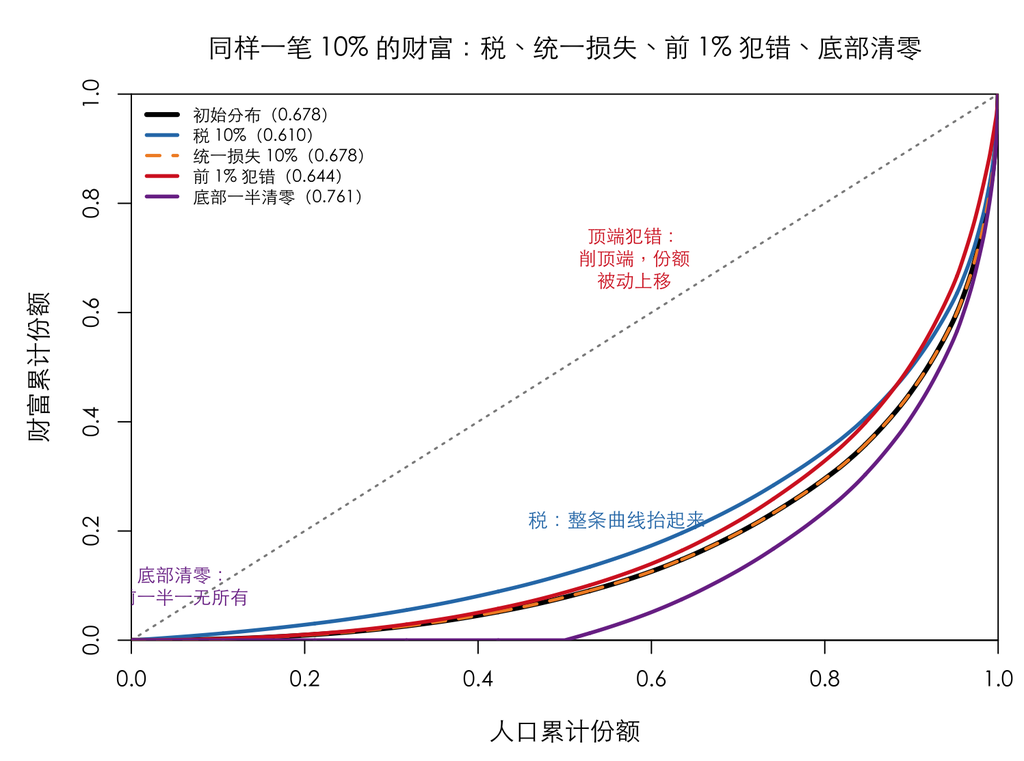

```r
## 同样一笔 10% 的财富：四种落地方式的 Lorenz 曲线（前 10% 犯错与
## 前 1% 犯错同向，图上只画后者）。
## 税把整条曲线抬起来；统一损失与原曲线重合；前 1% 犯错削顶端，份额被动上移；
## 底部清零把左下角压平。
inv_lorenz <- function(w){
  w <- sort(w); n <- length(w)
  data.frame(p = c(0, (1:n)/n), L = c(0, cumsum(w)/sum(w)))
}
inv_wipe2 <- inv_w0; inv_wipe2[inv_bot50] <- 0
L0 <- inv_lorenz(inv_w0); Lt <- inv_lorenz(inv_tax)
Lu <- inv_lorenz(inv_unif); Lp <- inv_lorenz(inv_prop1); Lw <- inv_lorenz(inv_wipe2)
par(mar = c(4.6, 5.0, 3.6, 1.0), family = "cjk", cex.lab = 1.15)
plot(NA, xlim = c(0, 1), ylim = c(0, 1), xaxs = "i", yaxs = "i",
     xlab = "人口累计份额", ylab = "财富累计份额",
     main = sprintf("同样一笔 %.0f%% 的财富：税、统一损失、前 1%% 犯错、底部清零", 100*inv_loss))
abline(0, 1, lty = 3, col = "gray55", lwd = 1.6)
lines(L0$p, L0$L, col = "black", lwd = 3.6)
lines(Lt$p, Lt$L, col = "#2C7BB6", lwd = 2.8)
lines(Lu$p, Lu$L, col = "#F28E2B", lwd = 2.4, lty = 2)
lines(Lp$p, Lp$L, col = "#D62728", lwd = 2.8)
lines(Lw$p, Lw$L, col = "#7B3294", lwd = 2.8)
legend("topleft", bty = "n", cex = 0.78,
       lwd = c(3.6, 2.8, 2.4, 2.8, 2.8), lty = c(1, 1, 2, 1, 1),
       col = c("black", "#2C7BB6", "#F28E2B", "#D62728", "#7B3294"),
       legend = c(sprintf("初始分布（%.3f）", inv_g0),
                  sprintf("税 %.0f%%（%.3f）", 100*inv_loss, gini(inv_tax)),
                  sprintf("统一损失 %.0f%%（%.3f）", 100*inv_loss, gini(inv_unif)),
                  sprintf("前 1%% 犯错（%.3f）", gini(inv_prop1)),
                  sprintf("底部一半清零（%.3f）", gini(inv_wipe2))))
text(0.56, 0.22, "税：整条曲线抬起来", col = "#2C7BB6", cex = 0.9)
text(0.58, 0.70, "顶端犯错：\n削顶端，份额\n被动上移", col = "#D62728", cex = 0.85)
text(0.06, 0.10, "底部清零：\n前一半一无所有", col = "#7B3294", cex = 0.85)
```

图里最显眼的是那条紫线：底部一半被清零之后，Lorenz 曲线在前 50% 是贴着横轴的——这不是“更平等”，而是把一半人直接踢出了财富分布。它的基尼是 0.761，比初始还高；前 1% 的占有反而升到 0.199。这条线不是一种可行的“投资错误”，而是算术上的警告：底部一半人的全部财富加起来只有总财富的 7.9%，连 10% 的冲击都吸收不了。把穷人的钱拿走，凑不出大数；它只会让穷人更穷，让基尼更高。

还有一条容易被忽略的边界：上表的“统一损失”是**每个人**都损失 10%。如果只抽中一部分人，而不是所有人，比例损失就变成了乘性噪声，基尼会被推高——那和第 5 章 σ 旋钮是同一类东西：乘性噪声改变的是分布形状，不只是把尺度整体缩小。这里让所有人都损失，是为了把“纯粹的比例缩放”单独拿出来；现实里的投资错误当然不会这么整齐。

```r
## 单个财富的半衰期：税是确定性的复利衰减；错误是每年以概率 p 损失 ℓ。
## 用期望对数收益率比较，避免把“期望值”与“典型路径”混在一起。
inv_tau <- 0.01; inv_p <- 0.10; inv_ell <- 0.50
inv_hl_tax <- log(0.5)/log(1 - inv_tau)
inv_hl_mis <- log(0.5)/(inv_p*log(1 - inv_ell))
inv_p_eq <- log(1 - inv_tau)/log(1 - inv_ell)
reg("inv_tau", inv_tau, "analytic", "§6.4 invest_halflife", "每年财富税率")
reg("inv_p", inv_p, "analytic", "§6.4 invest_halflife", "每年损失一半的概率")
reg("inv_ell", inv_ell, "analytic", "§6.4 invest_halflife", "一次错误损失的比例")
reg("inv_hl_tax", inv_hl_tax, "analytic", "§6.4 invest_halflife", "1% 财富税下单个财富的半衰期（年）")
reg("inv_hl_mis", inv_hl_mis, "analytic", "§6.4 invest_halflife", "每年 10% 概率损失一半时的半衰期（年）")
reg("inv_p_eq", inv_p_eq, "analytic", "§6.4 invest_halflife", "与 1% 税在期望对数上打平的年概率")
```

### 6.4.3 快，不等于均

那句流行语里最容易被记住的是“快”。这一点它是对的。一个每年 1% 的财富税，要让一笔财富减半，需要 69.0 年；一个每年 10% 的概率损失一半的投资，半衰期是 10.0 年。前者是复利式的慢慢磨，后者是跳变式的突然掉。要让两者在期望对数收益率上打平，每年的“损失一半”概率只需要 1.45%——10% 已经是它的 6.9 倍。

但快和均是两件事。税把收上来的钱按人头返还，底部的人拿到的比交出去的多；投资错误把钱销毁，底部的人一分钱拿不到。所以同样一笔 10%，税把基尼压到 0.610，前 1% 犯错只压到 0.644——虽然后者对前 1% 的打击更狠。一个让富人变穷的机制，不自动是一个让社会变平的机制；它可能只是把顶端换了一批人。

换人这件事，上表最后两列量的是留存率，而它们量的不是同一批人。前 1% 犯错那一行，前 1% 的留存率是 0.333——67% 的人掉出去了；但前 10% 的留存率仍是 1.000，因为掉出去的人还在前十里面，只是换了座位。前 10% 犯错那一行正好相反：前 10% 的留存率掉到 0.875，前 1% 的留存率却是 1.000——掉出去的主要是 90–99 分位那一段，最顶上那一小撮的位次没动。税和统一损失两行则都是 1.000，一个人都没换。这就是第 7 章那根轴：基尼说差距多大，留存率说位置会不会换人，而“前 1%”和“前 10%”的留存率还可以指向不同的故事。两件事可以同时发生，也可以分开发生。流行语描述的是换人，不是变平。

### 6.4.4 这是冲击，不是规则

还有一层，第 6.3.5 节已经量过一次：冲击改变状态，规则改变稳态。投资错误是一次冲击——它可以把某个人、某一代人打下去，但市场会继续按原来的规则运转，分布会重新长回去。税是每一轮都在拧的旋钮；错误是某一轮发生的事件。把一次错误调得很大，当然可以在短时间内把基尼砸下去；但下一轮没有错误，引擎还在，顶端还会重新长出来。要让错误成为持久的均等化力量，它必须变成一条规则——比如“每一代继承人都必须把一半财富押在一次集中投资上”——而那已经不是“投资错误”，而是一种没收。

所以，把“富人的投资”放进本文的框架，正确的做法不是给总图加一根向下的箭头，而是给它一个“谁承担”的参数：

- 如果错误均匀地落在所有人头上，它是比例缩放，基尼不动；如果是随机的、只落在部分人头上，它是乘性噪声，基尼可能上升。
- 如果错误集中在前 10% 或前 1%，它能把顶端削下去，被削掉那一档的留存率会掉，但基尼未必比税低，因为底部没有抬起来。
- 如果错误落在底部，它甚至凑不出同样大的宏观损失；把底部一半人的财富全部抹掉，基尼反而从 0.678 升到 0.761，前 1% 的占有反而升到 0.199。这不是均贫富，是把穷人打得更穷。

这三条合起来，正好回答了那句流行语：它描述的是一条真实的个体风险通道，不是一个可靠的分配机制。靠运气拿到资产的人，可能在一次集中投资里把钱还回去；但这件事对基尼的方向，取决于他是不是那 1%，以及他掉下去之后谁接上来。文献说，平均而言富人投得更好，继承控制权和横财是例外；例外足以毁掉一个家族，不足以把整个分布拉平。

把上面这些文献和模型压成一张表。家庭口径看净回报率，企业口径看资产营业利润率——两个口径不能混，但方向可以并排看。前八行是文献，后五行是本文模型。这里的“规则”是持续起作用的机制，“冲击”是一次发生的事件；“平均”是对整个人群的平均效应，“局部”是只落在某一小撮人身上。

各种因素对投资结果的方向：净回报、营业利润率与分布

| 因素 | 机制类型 | 对什么 · 方向 | 证据与量级 | 对分布的含义 |
| --- | --- | --- | --- | --- |
| 财富水平（净值） | 规则 · 平均（优势） | 家庭净回报 ↑（税后仍 ↑） | Fagereng 10→90：+18 pp（税后 +10）；Bach：顶端约股权溢价 | 拉开差距（§6.1.3 资本回报） |
| 金融素养 | 规则 · 平均（双刃） | 组合效率 ↑；未分散化损失 ↑ | Calvet 2007 | 净效应不定：效率与冒险同向 |
| 交易频率 | 规则 · 平均（错误） | 家庭净回报 ↓（毛回报相近） | Barber–Odean：最活跃 11.4% vs 市场 17.9% | 压低净回报；分布方向取决于谁交易更频繁 |
| 分散不足 | 规则 · 平均（错误） | 家庭净回报 ↓ | Calvet 2007 | 方向取决于谁更分散不足 |
| 不参与风险资产 | 规则 · 平均（错误） | 家庭净回报 ↓（参与者也未必有效率） | Calvet 2007 | 方向取决于谁不参与 |
| 继承控制权 | 冲击 · 局部 | 企业营业利润率 ↓ | Pérez-González 2006；Bennedsen 2007：至少 −4 pp | 削顶；对基尼方向不定 |
| 横财／彩票 | 冲击 · 局部 | 破产：只推迟，不避免 | Hankins 2011 | 削顶；对基尼方向不定 |
| 赌注变大（意外遗产） | 冲击 · 局部 | 投资错误 ↓，但经济上很小 | Andersen 2021 | 影响很小 |
| 投资错误：前 1% 承担 | 冲击 · 局部 | 自身财富 ↓ 54.6% | 本文模型 | 基尼 0.644；前 1% 留存 0.333 |
| 投资错误：前 10% 承担 | 冲击 · 局部 | 自身财富 ↓ 18.4% | 本文模型 | 基尼 0.649；前 10% 留存 0.875 |
| 统一损失：所有人 | 冲击 · 普遍 | 自身财富 ↓ 10% | 本文模型；解析恒等 | 基尼不动（0.678） |
| 税 + 人头返还 | 规则 · 普遍 | 净财富：顶端 ↓、底部 ↑ | 本文模型 | 基尼 0.610 |
| 投资错误：底部一半 | 冲击 · 局部 | 底部财富 ↓（全部清零） | 本文模型 | 基尼升至 0.761 |

这张表要读两件事。第一，真正把差距持续拉开的，是“规则 · 平均（优势）”那一行：财富越多，平均回报越高；交易频率、分散不足、不参与风险资产也会压低净回报，但它们是否拉大差距，取决于谁更容易犯这些错。第二，“冲击 · 局部”那一栏的方向取决于谁承担：落在顶端是削顶，落在底部是推高基尼。流行语只读第二栏，却把它当成了第一栏。

最后把这一节放回第 6 章的位置。第 6.5 节那张总图给每个机制一根箭头，因为它量的是“从 0.5 的基线出发，这个机制把基尼推到哪”。投资错误给不出单一箭头：同样的频率、同样的损失，换一个承担者，符号就反了。所以它不进总图，进那张“基尼量不到”的表——它真正改变的是位置会不会换人，而不是差距有多大。这也正是第 7 章要接着说的话。

## 6.5 三族合起来说明了什么

回到本章开头那张总图。现在每一根箭头都已经在前面某一节算过一遍：

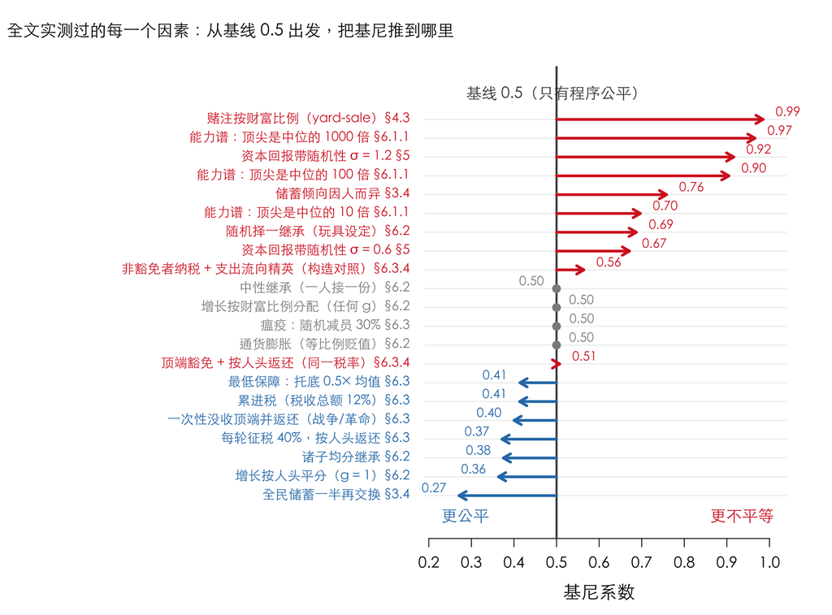

```r
f <- draw_fmap(FKEY_ALL, "全文实测过的每一个因素：从基线 0.5 出发，把基尼推到哪里")
```

```r
stopifnot(sum(f$neutral) == 4)     # 正文写的是"四个灰点"，数目对不上就炸
```

总图还是 21 根箭头；刚才那笔投资账不在图上，因为它给不出单一方向——下面那张表会把它收进去。

三件事一眼可见：

1. 推高的力量比压低的力量强得多。最强的向右箭头把基尼推到 0.985——而且那还是个不收敛的过程，跑得越久越高；最强的向左箭头只能压到 0.27。不平等上不封顶，下有硬底。
2. 中间那四个灰点是最反直觉的：按财富比例分配的增长、中性继承、通货膨胀、随机减员三成——四样几乎人人都以为会改变差距的东西，实测纹丝不动。原因各不相同，下面逐个说。
3. 能力差异不是一个点，是一段区间：10 倍谱推到 0.70，100 倍推到 0.90，1000 倍推到 0.97。所以“自然不平等有多重要”这个问题，在不同行业有不同答案。

但这张图漏了三样东西，而且漏得有道理。有些机制的效果根本不该用基尼去量——不是因为它们不重要，恰恰因为它们要紧的地方在别处：

| 因素 | 在哪一节 | 为什么基尼量不到 | 它真正改变的 |
| --- | --- | --- | --- |
| 信贷与清算规则 | §6.1.2 | 财富可以为负，基尼在这里失去意义 | 还剩多少人在场：等额授信 + 强制平仓，96.6% 出局 |
| 继承的流动性维度 | §6.2 | 基尼只管截面上的差距，不管谁站在哪 | 代际秩相关：中性 1.00 ／ 诸子均分 0.67 ／ 随机择一 0.18 |
| 富人的投资错误 | §6.4 | 方向由谁承担决定：统一损失不动，前 1% 犯错削顶端，底部犯错反而推高 | 前 1% 留存率：税 1.000 ／ 前 1% 犯错 0.333 |

这三条不是补遗，是提醒：上面那根横轴只有一个维度，而它压缩掉的东西——谁还在场、谁对着谁、位置会不会换人——经常比它留下的更要紧。把基尼系数翻译成分布：一张换算表已经从“分布形状”那一侧说过同一件事。

把这三族压成一句：

> 在本文的财富存量模型里，能把不平等推高的机制有很多，且都作用在存量上。而再分配不属于任何一族：它的效果由实际净归宿沿财富位次的形状、转移的规模与频率、以及这些相对于交换动力学的强弱共同决定。在本文测试到的参数范围内，当征收负担向中下层倾斜、且支出向顶端倾斜时，这套安排的净效应会发生符号反转。其余所有“均等化”效果，仍是某个双向机制在“对所有人一样”这个条件下的特例。

这句话有两个直接的推论。

其一，公平不是自动的。总图里向左的箭头没有一根是白给的：绝大多数依赖“规则对所有人一样”，而税收依赖的是另一个同样脆弱的条件——税基真的覆盖到顶端。而这个条件本身不会自己维持——它需要被主动维持。这就是为什么第 5 章末尾那台“反向支配等级”的装置重要：它维持的正是这个条件。

其二，“程序公平”这四个字在这里获得了精确的含义。它不是一句道德口号，而是这张总图上把整整一族机制钉在中性位置的那个开关。松开它，那一族立刻倒向推高的一侧——而且倒得比任何单一因素都狠（0.758、0.92）。

# 7 一个数不够：基尼之外还要看什么

前面每一章都在问“不平等从哪来、往哪走”。这一章换一个问题：要说清楚一个社会的不平等，一个数够不够。

答案已经被前面撞见过三次，只是每次都被就地处理掉了：

- 第 4.6 节：两个社会可以有一模一样的基尼，一个是“同一个人的一生摊开”，一个是“一份出生名单”——基尼分不出它们。
- 把基尼系数翻译成分布：一张换算表：给定基尼，分布的形状仍然自由——同为 0.5，Pareto 在百倍均值处的概率比指数高约 $10^{40}$ 倍——基尼定不住形状。
- 第 6.2.2 节：盖茨比曲线的纵轴 $\beta=\rho\cdot\sigma_c/\sigma_p$ 里含着一个离散度之比——横轴的东西漏进了纵轴。

这一章把这条线接下去，再走一步：阶层流动性分不出“能翻身”和“被随机重排”，也分不出位置牢在什么上。

结构是两根通用轴：基尼与阶层流动性——只要机制能在同一台交换机器上复算，两个都能算。

## 7.1 第二根轴：阶层流动性

第 6 章的每一个因素都只报了一个数：基尼。但第 4.5–4.6 节已经论证过，基尼是个截面量——它说不出同一个人明年还在不在那个位置。第 6.2 节量继承时顺手补了一个流动性指标，结果发现基尼和阶层流动性可以各走各的。那为什么不对第 6 章的因素都算一遍？

但“流动性”这个词底下压着两件不同的事，而它们的价值方向相反。这一点不说破，后面全是糊的：

- **代际阶层流动性**：父辈的位置能不能预测子辈。第 6.2 节那三行继承规则量过（报的是父子位次的秩相关，越高越不流动）——中性继承 1.00、诸子均分 0.67、随机择一继承 0.18。
- **代内阶层流动性**：同一个人在一生之内，隔一段时间之后还在不在原来的位置。

同一个“流动性”，你想要的方向是相反的。在第 4.6 节写明的那些条件下：

|  | 我们希望它 | 因为 |
| --- | --- | --- |
| 代际流动性 | 高 | 位置若能由父辈预测，预测力来自财富传递而非本人——穷人的后代该有机会上去，而只靠出身占着高位的该掉下来 |
| 代内流动性 | 未必要高 | 如果一个人确实更能干，那他持续挣得更多不是问题——问题是位置到底追踪着什么 |

这个不对称是本章后半段的全部动机。代际那一侧，第 6.2 节已经量完了；这一节量代内那一侧；而“位置到底追踪着什么”——流动性这根轴根本回答不了——要留到下一节。

需要一个对代内适用、且对所有机制都能算的指标。代际流动性只有在有“代”的时候才有意义，而第 6 章大多数机制（能力、储蓄、资本回报、税收、增长）根本不涉及代际。换一个更基本的量：

> **位次秩相关** $\rho$ $=$ 相隔 $H$ 轮的两次财富排名之间的**秩相关**（下面取 $H=100$，由 `run2()` 的默认参数给出）。它是阶层流动性的反向读数：$\rho$ 越高，流动性越低。

它问的是“过了这么久，还是原来那批人在上面吗”。下面这张图里每个机制一行，基尼记在 `cfg$g`、秩相关记在 `cfg$r`（整表见 `docs/data/two_axes.csv`）；后文凡引用图上读数，都是从这两列取的。$\rho=1$ 是位置完全冻结、流动性为零；$\rho=0$ 是位次之间没有单调关联、流动性拉满（注意 $\rho=0$ 不等于”毫无关系”，它只排除单调的秩关联）。取 $H=100$ 轮：

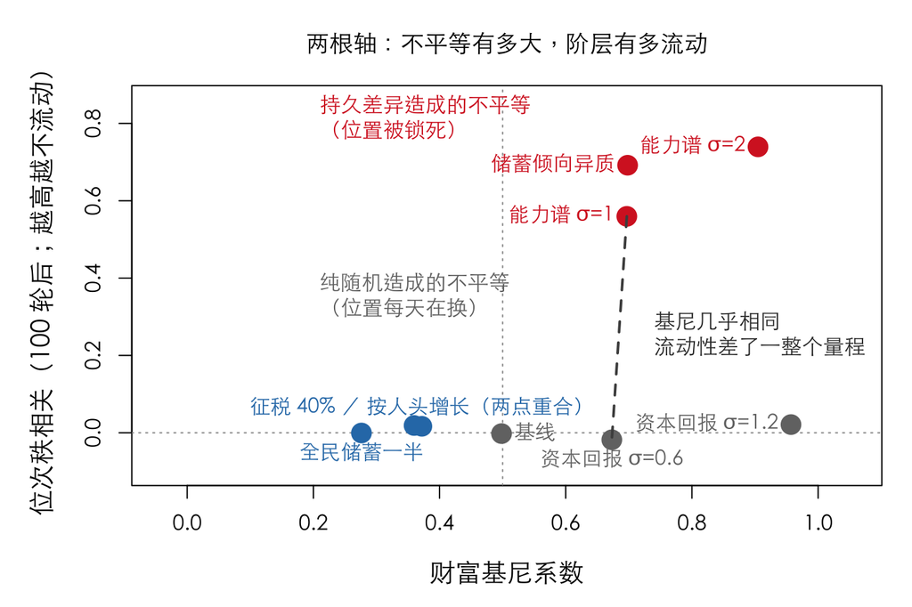

```r
## run1 的扩展版：同一台交换机器，同时吐出基尼和位次秩相关
run2 <- function(N = 1500, rounds = 400, mode = "base", p = 0, seed = 1, H = 100){
  set.seed(seed); w <- rep(1, N); half <- N/2
  a <- if (mode == "ability") exp(rnorm(N, 0, p)) else rep(1, N); a <- a/mean(a)
  lam <- switch(mode, save_all = rep(p, N), save_het = runif(N), rep(0, N))
  w0 <- NULL
  for (r in 1:rounds){
    if (r == rounds - H + 1) w0 <- w                              # 记下恰好 H 轮前的位置
    if (mode == "tax" && p > 0){ tx <- p*w; w <- w - tx + sum(tx)/N }
    if (mode == "growflat")     w <- w + p*mean(w)
    if (mode == "capital")      w <- w*exp(-p^2/2 + p*rnorm(N))
    idx <- sample.int(N); i <- idx[1:half]; j <- idx[(half+1):N]
    pooled <- (1-lam[i])*w[i] + (1-lam[j])*w[j]
    e <- if (mode == "ability") rbeta(half, a[i], a[j]) else runif(half)
    w[i] <- lam[i]*w[i] + e*pooled; w[j] <- lam[j]*w[j] + (1-e)*pooled
    if (mode == "capital") w <- w/mean(w)
  }
  c(gini = gini(w), rho = cor(rank(w0), rank(w)))
}
cfg <- data.frame(
  mode = c("base", "save_all", "tax", "growflat", "capital", "capital",
           "save_het", "ability", "ability"),
  p    = c(0, 0.5, 0.4, 1, 0.6, 1.2, 0, 1, 2),
  lab  = c("基线", "全民储蓄一半", "征税 40% ／ 按人头增长（两点重合）", "",
           "资本回报 σ=0.6", "资本回报 σ=1.2", "储蓄倾向异质",
           "能力谱 σ=1", "能力谱 σ=2"), stringsAsFactors = FALSE)
MM <- t(mapply(function(m, p) run2(mode = m, p = p), cfg$mode, cfg$p))   # 不用 M：§5 已占用
cfg$g <- MM[, 1]; cfg$r <- MM[, 2]

ACC <- "#D62728"; BLU <- "#2C7BB6"; GRY <- "gray45"
cfg$col <- ifelse(cfg$r > 0.2, ACC, ifelse(cfg$g < 0.45, BLU, GRY))
par(mar = c(4.8, 5.2, 3.4, 1.2), cex.lab = 1.22, cex.main = 1.12, family = "cjk")
plot(NA, xlim = range(cfg$g) + c(-0.32, 0.10), ylim = range(c(cfg$r, 0)) + c(-0.08, 0.12),
     xlab = "财富基尼系数",
     ylab = "位次秩相关（100 轮后；越高越不流动）",
     main = "两根轴：不平等有多大，阶层有多流动")
abline(h = 0, lty = 3, col = "gray60"); abline(v = 0.5, lty = 3, col = "gray60")
text(0.19, 0.80, "持久差异造成的不平等\n（位置被锁死）", col = ACC, cex = 1.0, pos = 4)
text(0.19, 0.34, "纯随机造成的不平等\n（位置每天在换）", col = GRY, cex = 1.0, pos = 4)
points(cfg$g, cfg$r, pch = 21, bg = cfg$col, col = cfg$col, cex = 1.9, lwd = 2)
text(cfg$g, cfg$r, cfg$lab, pos = c(4,1,3,1,1,2,2,2,2), cex = 0.98, col = cfg$col)
i1 <- which(cfg$lab == "能力谱 σ=1"); i2 <- which(cfg$lab == "资本回报 σ=0.6")
segments(cfg$g[i1], cfg$r[i1], cfg$g[i2], cfg$r[i2], lty = 2, lwd = 2, col = "gray30")
text(0.72, 0.24, "基尼几乎相同\n流动性差了一整个量程", cex = 1.0, col = "gray20", pos = 4)
```

（这台 `run2()` 就是第 6.1.1 节 `run1()` 的扩展版，只多存了一次中途快照。它在基线、储蓄、能力这几档上复现了前面各节的基尼（资本回报那两档的设定与第 5 章不同——那里带 0.01 漂移、$N$ 与轮数也不同，故只可比不可等同）：基线 0.50、全民储蓄 0.28、能力谱 σ=1 是 0.70、资本回报 σ=0.6 是 0.67——所以两根轴上的数是可比的。）

这张图上最要紧的是那条虚线连起来的两个点。

| 机制 | 不平等从哪来 | 基尼系数 | 位次秩相关 |
| --- | --- | --- | --- |
| 能力谱 σ = 1 | 人和人之间持久的能力差异 | 0.70 | +0.56 |
| 资本回报 σ = 0.6 | 人人相同的回报率，但回报带涨落 | 0.67 | -0.02 |

基尼差不多（0.70 对 0.67），位次秩相关却是 +0.56 对 -0.02 ——一个明显偏低、一个基本拉满。（前者不是”完全冻结”（那要 $\rho=1$），但已经是一个位置相当粘的社会；后者的 $\rho$ 落在零附近。）这就是第 4.6 节那两个世界，只不过这次不是构造出来的，而是这一章自己的两个机制跑出来的。用基尼去管理这两个社会，会把它们当成同一件事；但生在其中一个和生在另一个，是完全不同的人生。

整张图给出一条比单看基尼干净得多的规律：

> 在所测的这几个方案里，位次被锁死只出现在带持久个体差异的那一族，与随机性的强弱无关。（这是对测过的设定与这个时间跨度而言；而且 $\rho\approx0$ 只说明没有单调的秩关联，不等于“毫无关系”。）

三组证据：

- 红色那一族——能力谱、储蓄倾向异质——秩相关都在 0.56 以上（图里按 $\rho>0.2$ 上色）。它们的共同点是每个人身上挂着一个不随时间变化的标签（能力、储蓄率），标签决定了他长期落在哪。基尼越高，标签越显眼。
- 灰色那一族——基线与资本回报——把基尼一路推到 0.96，秩相关却始终在零附近、流动性拉满。涨落是每轮重抽的，没人有持久优势：今天的富人只是最近连着走运的人。纯随机造成的不平等确实不让位置持久（代际那一侧见第 6.2 节，本节量的是一生之内）。

  但这里要把一个顺口的安慰话拆开：$\rho\approx0$ 有两种完全不同的来源——位置可由本人改变（那是真流动性），或者位置被随机与制度规则重排（那只是波动）。$\rho$ 本身分不出这两者。而这个模型里根本没有能动性变量，所以它无法识别自主流动；观察到的位置变动全部来自它自己施加的随机与制度规则。因此本文所有“流动性”数字量的都是“位置有没有换人”，不是“能不能翻身”。
- 蓝色那一族——税收、按人头增长、全民储蓄——把基尼压低，而秩相关同样是零。它们不锁人。这一点值得单独说：这些方案降低不平等，并不以牺牲流动性为代价——图上没有任何一个点同时具备低基尼和低流动性。（限定：这里跑的税收是“全员同比例征、按人头返还”这一种；第 6.3.4 节那些顶端豁免的方案没有放进这张图，它们连符号都不同。）

顺带看一眼第 6.2 节那个结论：征税 40% 和按人头平分的增长（$g=1$）在两根轴上几乎落在同一个点（0.37 / +0.02 对 0.36 / +0.02）。

但要把话说准：它们属于同一族操作，不是这两个参数值恰好等价。按均值归一之后，按人头增长 $g$ 给出 $r'=\frac{r+g}{1+g}$，而征税 $\tau$ 给出 $r'=(1-\tau)r+\tau$；配系数得
$$\tau=\frac{g}{1+g}$$
所以 $g=1$ 对应的是 $\tau=0.5$，而不是 0.4。这两点之所以看起来重合，是因为在那一段基尼曲线已经很平——是数值巧合，不是恒等式。恒等的是那一族：凡是给每个人加同一个常数的操作，都是同一个操作，区别只在钱从哪来。

这两根轴不是必然分开的——什么时候分、什么时候不分，别人量过。Bertotti 与 Modanese 在一个同样是动理学的模型里扫过“税率差 × 福利资格审查”这个两参数平面，发现基尼的等值线与流动性的等值线重合到千分之一 (Bertotti and Modanese 2016)；同一组人随后又报告，在多种设定下两者的相关系数一致为负，与盖茨比曲线相符 (Bertotti et al. 2017)。

这和上面那张图不冲突，冲突的是读法。两处的口径先要对清楚：他们的流动性是**向上跃迁概率**（“单位时间内一个人升入上一个收入档的概率，按各档加权平均”），有方向、在离散的收入档之间；本文的是位次秩相关，对称、连续。两个数不能直接比。

> 所以正确的说法不是“基尼和流动性无关”，而是：在一族机制内部它们可以紧紧绑在一起，跨机制族就松开。共线性是受限参数族的性质，不是普遍规律。而现实中的政策讨论恰恰是跨机制族的——税收、教育、遗产、资本市场不在同一个平面上。

（顺带一提，Bertotti 与 Modanese 那篇末尾把经济流动性类比成气体温度，并指出玻尔兹曼–吉布斯指数分布的基尼与温度无关、恒等于 $1/2$ (Bertotti and Modanese 2016)——正是本文第 3 章那条基线。“温度”这根线是姊妹篇《公平与效率：同一个温度》的正题。）

一句话把两根轴合起来： 基尼问“差距有多大”，代内阶层流动性问“这个差距是不是同一批人的”。

推高不平等的机制里，只有一部分同时让位置高度持久；而压低不平等的机制，没有一个是靠固定位置做到的。

但这根轴到此为止——它说不出位置牢在什么上。图上红色那一族里，能力谱 σ=1 那一点的秩相关是 0.56，储蓄倾向异质那一点是 0.69，两个都高；而它们的持久标签按设定就是两回事——一个是模型里那个叫“能力”的固定标签，另一个是跟它无关的储蓄习惯。

这不是“两个数碰巧接近”那么弱的说法。$\rho$ 是两个财富秩向量之间的相关系数，它的定义里没有任何一项指向“位置为什么持久”。而且光说“公式里没有这一项”还不够——存在两个世界给出完全相同的 $\rho$，追踪的却是不同的东西：取 $\rho = 1$，世界甲里财富秩恒等于能力秩，世界乙里财富秩恒等于储蓄倾向秩、而能力与财富独立。两边读数一模一样，位置却牢在完全不同的东西上。所以 $\rho$ 单独一个数，识别不出位置在追踪什么。

要把它们分开，需要的不是更精细的秩相关，而是一个财富与能力的联合统计量——本文没有算，下一节说明为什么。（还有更麻烦的一层：即便造出那把尺，位置也可能反过来塑造能力——运气不好、久无机会施展的人，能力本身会退化。而本文报告的这些截面关联，本身不足以判定是能力决定了位置，还是位置塑造了能力。）

$\rho$ 藏起来的还不止这一件：它把上下也抹平了。第 4.6 节说过，位次流动是零和的——有人上去必然有人下来。但“上去”和“下来”未必一样容易。把全局那一个 $\rho$ 按出发时所在的十分位拆开（结果存在 `FC`，落盘为 `docs/data/floor_ceiling.csv`），看每一格的人过了 $H$ 轮之后还留在原格的比例（完全随机重排时应处处等于 0.1）：

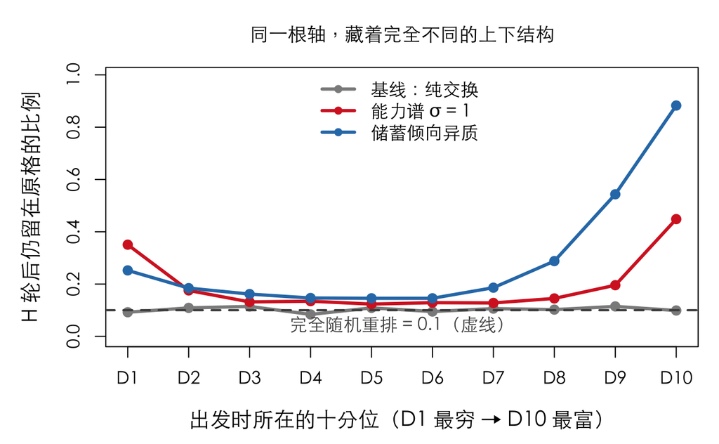

```r
## 把位次流动按"出发时在哪一格"拆开：留在原十分位的比例。
## 完全随机重排时每格都是 0.1；高于 0.1 就是"粘住了"。
snap2 <- function(mode = "base", p = 0, N = 1500, rounds = 400, H = 100, seed = 1){
  set.seed(seed); w <- rep(1, N); half <- N/2
  a <- if (mode == "ability") exp(rnorm(N, 0, p)) else rep(1, N); a <- a/mean(a)
  lam <- if (mode == "save_het") runif(N) else rep(0, N)
  w0 <- NULL
  for (r in 1:rounds){
    if (r == rounds - H + 1) w0 <- w
    idx <- sample.int(N); i <- idx[1:half]; j <- idx[(half+1):N]
    pooled <- (1-lam[i])*w[i] + (1-lam[j])*w[j]
    e <- if (mode == "ability") rbeta(half, a[i], a[j]) else runif(half)
    w[i] <- lam[i]*w[i] + e*pooled; w[j] <- lam[j]*w[j] + (1-e)*pooled
  }
  list(w0 = w0, w1 = w)
}
dec10 <- function(x) cut(rank(x, ties.method = "first"),
                         breaks = quantile(seq_along(x), 0:10/10),
                         include.lowest = TRUE, labels = FALSE)
stay <- function(mode, p, seeds = 1:12)
  rowMeans(sapply(seeds, function(sd){
    S <- snap2(mode, p, seed = sd); d0 <- dec10(S$w0); d1 <- dec10(S$w1)
    sapply(1:10, function(k) mean(d1[d0 == k] == k)) }))
FC <- cbind(`基线：纯交换` = stay("base", 0),
            `能力谱 σ = 1`  = stay("ability", 1),
            `储蓄倾向异质`  = stay("save_het", 0))

COLF <- c("gray55", "#D62728", "#2C7BB6")
par(mar = c(4.6, 5.0, 3.2, 1.0), cex.lab = 1.2, cex.main = 1.08, family = "cjk")
matplot(1:10, FC, type = "o", pch = 16, lty = 1, lwd = 3, cex = 1.3, col = COLF,
        ylim = c(0, max(FC)*1.12), xaxt = "n",
        xlab = "出发时所在的十分位（D1 最穷 → D10 最富）",
        ylab = "H 轮后仍留在原格的比例", main = "同一根轴，藏着完全不同的上下结构")
axis(1, at = 1:10, labels = paste0("D", 1:10))
abline(h = 0.1, lty = 2, lwd = 2, col = "gray30")
text(5.5, 0.045, "完全随机重排 = 0.1（虚线）", col = "gray30", cex = 1.02)
legend("top", colnames(FC), col = COLF, lwd = 3, pch = 16, bty = "n", cex = 1.02)
```

```r
stopifnot(all(abs(FC[, 1] - 0.1) < 0.03))       # 基线应处处贴着 0.1
```

三条线说了三件不同的事。

- 基线（灰）处处贴在 0.1 上。纯交换里没有粘性，连底部都没有——0 那堵墙并不制造 sticky floor。这一条值得说破，因为“穷人翻不了身”常被当成随机性的自然后果，而在这台机器里它不成立。
- 能力谱（红）是一条对称的 U。两端粘（D1 0.35、D10 0.45），中间松。上下大致一样牢——那个标签在分布两端同样起作用。
- 储蓄倾向异质（蓝）是一条歪掉的 U。底端 0.25，顶端 0.88——顶端几乎冻死，底端只是稍微粘一点。同一个机制，上下差了三倍还多。

而这两条线的全局 $\rho$ 是接近的（能力谱 0.56、储蓄异质 0.69）。也就是说：同一个流动性读数，可以是“上下一样牢”，也可以是“顶端锁死、底端还在换人”。这两种社会对身处其中的人完全不是一回事，而那一个数把它们报成了同一件事。

## 7.2 本文的两条模型边界

上一节停在一个缺口上。它是本文两条模型边界里的一条，两条一起说完，这一章才收得干净。

边界一：没有一个所有机制共用的能力变量，也没有算过财富与能力的联合量。这条容易说岔，所以要讲准：本文有个体禀赋——第 6.1.1 节和上一节图里那个 `a` 就是。缺的是另外两样：`a` 只活在能力那几档实验里，税收、继承、储蓄、通胀这些机制里根本没有它；而本文从头到尾报的都是财富这一边的量（基尼、秩自相关），没有算过任何财富 × 能力的联合统计量。

所以“位置在追踪什么”这一问，本文答不了——但要看清它为什么答不了。答它并不需要生产模型：财富位次与能力位次之间有多少关联，是个纯统计问题。生产模型是再下一步才要的——把“配置对上了能力”读成“效率更高”，那才需要一台能直接算产出的机器。这两件事常被混作一件，其实差着一层。

边界二：没有生产，所以这个模型里没有“年收入”这个东西。第 4.4 节量过一件事：本模型的收入基尼是核算窗口的函数——1 轮 0.55，100 轮 0.06，1000 轮 0.02。原因很直白：岛上的“收入”只是别人转过来的金币，而现实中绝大部分收入是被生产出来的工资。窗口一变数就变，它压根没有一个稳定的年收入可言。

这条限制的东西比看上去多。凡是要先有“时间尺度确定的年收入”才谈得上的量，在这个模型里都无从定义——第 4.6 节那个收入的永久／暂时成分分解就是最典型的一个。它不是难算，是没有可算的对象。

一句话收尾：纯交换模型能说清楚存量怎么分布，说不清楚流量怎么波动。本文所有关于流动性的话，都是关于财富位次的，不是关于收入的。

# 8 结语：回到卢梭

海盗多年后回到岛上，看到的是一个指数分布，基尼 $1/2$。没有人做错什么。它只要三样东西：金币总量守恒，财富有下界，每一笔交易对双方一样公平。

卢梭的账本只有两栏，自然的与人造的。本文补上第三栏：运气。这一栏不是一个可以从人造那栏里直接减掉的常数。$1/2$ 是这一台交换机器的基线：每笔交易的赌注不随财富放大，规则对谁都一样。换一条交换规则，形状就跟着换；赌注按财富比例下注的 yard-sale 同样守恒、同样公平，却一路走向一人独占（第 4.3 节）。所以读一个现实的基尼，该问的是：和同一套交换规则下的运气基线相比，它高在哪里、低在哪里，多出来的部分是哪一族机制推上去的。

能坏到什么程度，第 5 章给了位置。让回报带上涨落 $\sigma$，方差在 $\sigma\approx0.64$ 先失去意义，均值在 $\sigma=1$ 失去意义：典型的人趋于零，平均数不动，靠越来越少的人撑着。基尼在这两处都光滑通过。要看不平等是不是变了性质，看的是尾巴还有没有均值，不是基尼的读数。

能改什么，第 6 章那张总图给了比例。推高的机制多，也强：最强的一根把基尼推到 0.99，压低的最多压到 0.27。压低的那些大多依赖一个条件：规则对所有人一样。税收另有两个条件：税基覆盖到顶端，支出不流向顶端；两样都反过来时（第 6.3.4 节），同样叫再分配的安排会把基尼推到 0.56。这些条件都不会自己维持。卢梭那位圈地者在模型里就是这个样子：规则对他和对别人不一样。

最后，一个数不够。基尼说差距有多大，不说是不是同一批人站在上面。基尼相近的两种机制，位次可以一个冻住、一个不停重排（第 7.1 节）。就算量出位置粘不粘，也还说不出它粘在什么上，是能力，还是储蓄习惯、出身。要回答这一问，需要财富与能力的联合统计量，以及一台有生产的机器；这是《公平与效率：同一个温度》接着要做的事。

第戎科学院问的是：人类不平等的起源是什么？卢梭给了两个来源。把他的思想实验跑一遍，会多出第三个；这一个不必猜，可以算出来。

*本文每一张图表背后的数据在每次 knit 时自动写入 `docs/data/`，逐项对照表见 `docs/provenance-registry.md`。*

*本文用到的最大熵、Lagrange 乘子、KL 散度、玻尔兹曼分布，完整推导在[《从熵到分布：指数、幂律、正态与玻尔兹曼的统一逻辑》](https://nyuhuyang.github.io/notes/exp_normal_boltzmann_zh.html)里，每次用到都就地给出章节链接。*

# 参考文献

Andersen, Steffen, Abhiroop Mukherjee, and Kasper Meisner Nielsen. 2021. “Stakes and Mistakes.” Unpublished manuscript.

Angle, John. 1986. “The Surplus Theory of Social Stratification and the Size Distribution of Personal Wealth.” *Social Forces* 65 (2): 293–326. https://doi.org/10.2307/2578675.

Bach, Laurent, Laurent E. Calvet, and Paolo Sodini. 2020. “Rich Pickings? Risk, Return, and Skill in Household Wealth.” *American Economic Review* 110 (9): 2703–47. https://doi.org/10.1257/aer.20170666.

Barber, Brad M., and Terrance Odean. 2000. “Trading Is Hazardous to Your Wealth: The Common Stock Investment Performance of Individual Investors.” *Journal of Finance* 55 (2): 773–806. https://doi.org/10.1111/0022-1082.00226.

Becker, Gary S., and Nigel Tomes. 1979. “An Equilibrium Theory of the Distribution of Income and Intergenerational Mobility.” *Journal of Political Economy* 87 (6): 1153–89.

Bengtsson, Erik, Anna Missiaia, Mats Olsson, and Patrick Svensson. 2018. “Wealth Inequality in Sweden, 1750–1900.” *The Economic History Review* 71 (3): 772–94. https://doi.org/10.1111/ehr.12576.

Benhabib, Jess, and Alberto Bisin. 2018. “Skewed Wealth Distributions: Theory and Empirics.” *Journal of Economic Literature* 56 (4): 1261–91. https://doi.org/10.1257/jel.20161390.

Bennedsen, Morten, Kasper Meisner Nielsen, Francisco Pérez-González, and Daniel Wolfenzon. 2007. “Inside the Family Firm: The Role of Families in Succession Decisions and Performance.” *Quarterly Journal of Economics* 122 (2): 647–91. https://doi.org/10.1162/qjec.122.2.647.

Bertotti, Maria Letizia, Amit K. Chattopadhyay, and Giovanni Modanese. 2017. “Correlation Between Gini Index and Mobility in a Stochastic Kinetic Model of Economic Exchange.” *Results in Physics* 7: 2081–84. https://doi.org/10.1016/j.rinp.2017.05.031.

Bertotti, Maria Letizia, and Giovanni Modanese. 2016. “Economic Inequality and Mobility in Kinetic Models for Social Sciences.” *The European Physical Journal Special Topics* 225: 1945–58. https://doi.org/10.1140/epjst/e2015-50117-8.

Biggins, J. D. 1977. “Martingale Convergence in the Branching Random Walk.” *Journal of Applied Probability* 14 (1): 25–37. https://doi.org/10.1017/s0021900200104644.

Boehm, Christopher. 1999. *Hierarchy in the Forest: The Evolution of Egalitarian Behavior*. Harvard University Press.

Boghosian, Bruce M. 2019. “The Inescapable Casino.” *Scientific American* 321 (5): 70–77.

Boghosian, Bruce M., Adrian Devitt-Lee, and Hongyan Wang. 2016. “The Growth of Oligarchy in a Yard-Sale Model of Asset Exchange: A Logistic Equation for Wealth Condensation.” *Proceedings of the 1st International Conference on Complex Information Systems (COMPLEXIS 2016)*, 187–93. https://doi.org/10.5220/0005956501870193.

Boltzmann, Ludwig. 1877. “Ueber Die Beziehung Zwischen Dem Zweiten Hauptsatze Der Mechanischen Wärmetheorie Und Der Wahrscheinlichkeitsrechnung Respektive Den Sätzen Über Das Wärmegleichgewicht.” *Sitzungsberichte Der Kaiserlichen Akademie Der Wissenschaften. Mathematisch-Naturwissenschaftliche Classe* 76: 373–435. https://doi.org/10.3390/e17041971.

Bouchaud, Jean-Philippe, and Marc Mézard. 2000. “Wealth Condensation in a Simple Model of Economy.” *Physica A: Statistical Mechanics and Its Applications* 282 (3-4): 536–45. https://doi.org/10.1016/S0378-4371(00)00205-3.

Boudin, Laurent, and Lara Trussardi. 2024. “Concentration Effects in a Kinetic Model with Wealth and Knowledge Exchanges.” *La Matematica* 3: 166–95. https://doi.org/10.1007/s44007-023-00081-y.

Bricker, Jesse, Lisa J. Dettling, Alice Henriques, et al. 2017. “Changes in U.S. Family Finances from 2013 to 2016: Evidence from the Survey of Consumer Finances.” *Federal Reserve Bulletin* 103 (3). https://www.federalreserve.gov/publications/files/scf17.pdf.

Buraczewski, Dariusz. 2009. “On Tails of Fixed Points of the Smoothing Transform in the Boundary Case.” *Stochastic Processes and Their Applications* 119 (11): 3955–61. https://doi.org/10.1016/j.spa.2009.09.005.

Calvet, Laurent E., John Y. Campbell, and Paolo Sodini. 2007. “Down or Out: Assessing the Welfare Costs of Household Investment Mistakes.” *Journal of Political Economy* 115 (5): 707–47. https://doi.org/10.1086/524204.

Chakrabarti, Bikas K., Anirban Chakraborti, Satya R. Chakravarty, and Arnab Chatterjee. 2013. *Econophysics of Income and Wealth Distributions*. Cambridge University Press. https://doi.org/10.1017/CBO9781139004169.

Chakraborti, Anirban. 2002. “Distributions of Money in Model Markets of Economy.” *International Journal of Modern Physics C* 13 (10): 1315–21. https://doi.org/10.1142/S0129183102003905.

Chakraborti, Anirban, and Bikas K. Chakrabarti. 2000. “Statistical Mechanics of Money: How Saving Propensity Affects Its Distribution.” *The European Physical Journal B* 17 (1): 167–70. https://doi.org/10.1007/s100510070173.

Champernowne, D. G. 1953. “A Model of Income Distribution.” *The Economic Journal* 63 (250): 318–51. https://doi.org/10.2307/2227127.

Chatterjee, Arnab, and Bikas K. Chakrabarti. 2007. “Kinetic Exchange Models for Income and Wealth Distributions.” *The European Physical Journal B* 60 (2): 135–49. https://doi.org/10.1140/epjb/e2007-00343-8.

Chatterjee, Arnab, Bikas K. Chakrabarti, and S. S. Manna. 2004. “Pareto Law in a Kinetic Model of Market with Random Saving Propensity.” *Physica A: Statistical Mechanics and Its Applications* 335 (1-2): 155–63. https://doi.org/10.1016/j.physa.2003.11.014.

Chetty, Raj, David Grusky, Maximilian Hell, Nathaniel Hendren, Robert Manduca, and Jimmy Narang. 2017. “The Fading American Dream: Trends in Absolute Income Mobility Since 1940.” *Science* 356 (6336): 398–406. https://doi.org/10.1126/science.aal4617.

Chetty, Raj, Nathaniel Hendren, Patrick Kline, and Emmanuel Saez. 2014. “Where Is the Land of Opportunity? The Geography of Intergenerational Mobility in the United States.” *The Quarterly Journal of Economics* 129 (4): 1553–623. https://doi.org/10.1093/qje/qju022.

Cooray, Kahadawala, and Malwane M. A. Ananda. 2005. “Modeling Actuarial Data with a Composite Lognormal-Pareto Model.” *Scandinavian Actuarial Journal* 2005 (5): 321–34. https://doi.org/10.1080/03461230510009763.

Corak, Miles. 2013. “Income Inequality, Equality of Opportunity, and Intergenerational Mobility.” *Journal of Economic Perspectives* 27 (3): 79–102. https://doi.org/10.1257/jep.27.3.79.

Cunha, Flavio, and James J. Heckman. 2007. “The Technology of Skill Formation.” *American Economic Review* 97 (2): 31–47. https://doi.org/10.1257/aer.97.2.31.

Cunha, Flavio, James J. Heckman, and Susanne M. Schennach. 2010. “Estimating the Technology of Cognitive and Noncognitive Skill Formation.” *Econometrica* 78 (3): 883–931. https://doi.org/10.3982/ECTA6551.

Deng, Kent. 2021. *Ultra-Low Tax Regime in Imperial China, 1368–1911*. Economic History Working Paper No. 324. London School of Economics; Political Science.

Diamond, Jared. 1997. *Guns, Germs, and Steel: The Fates of Human Societies*. W. W. Norton.

Drăgulescu, Adrian, and Victor M. Yakovenko. 2000. “Statistical Mechanics of Money.” *The European Physical Journal B* 17 (4): 723–29. https://doi.org/10.1007/s100510070114.

Drăgulescu, Adrian, and Victor M. Yakovenko. 2001a. “Evidence for the Exponential Distribution of Income in the USA.” *The European Physical Journal B* 20: 585–89. https://doi.org/10.1007/PL00011112.

Drăgulescu, Adrian, and Victor M. Yakovenko. 2001b. “Exponential and Power-Law Probability Distributions of Wealth and Income in the United Kingdom and the United States.” *Physica A: Statistical Mechanics and Its Applications* 299 (1–2): 213–21. https://doi.org/10.1016/S0378-4371(01)00298-9.

Durrett, Richard, and Thomas M. Liggett. 1983. “Fixed Points of the Smoothing Transformation.” *Zeitschrift für Wahrscheinlichkeitstheorie Und Verwandte Gebiete* 64 (3): 275–301. https://doi.org/10.1007/bf00532962.

Eisinger, Jesse, Jeff Ernsthausen, and Paul Kiel. 2021. *The Secret IRS Files: Trove of Never-Before-Seen Records Reveal How the Wealthiest Avoid Income Tax*. ProPublica.

Fagereng, Andreas, Luigi Guiso, Davide Malacrino, and Luigi Pistaferri. 2020. “Heterogeneity and Persistence in Returns to Wealth.” *Econometrica* 88 (1): 115–70. https://doi.org/10.3982/ECTA14835.

Farrell, Diana, Fiona Greig, and Chenxi Yu. 2019. *Weathering Volatility 2.0: A Monthly Stress Test to Guide Savings*. JPMorgan Chase Institute.

Gabaix, Xavier. 2009. “Power Laws in Economics and Finance.” *Annual Review of Economics* 1: 255–94. https://doi.org/10.1146/annurev.economics.050708.142940.

Gallegati, Mauro, Steve Keen, Thomas Lux, and Paul Ormerod. 2006. “Worrying Trends in Econophysics.” *Physica A: Statistical Mechanics and Its Applications* 370 (1): 1–6. https://doi.org/10.1016/j.physa.2006.04.029.

Galton, Francis. 1886. “Regression Towards Mediocrity in Hereditary Stature.” *The Journal of the Anthropological Institute of Great Britain and Ireland* 15: 246–63. https://doi.org/10.2307/2841583.

Gottschalk, Peter, and Robert Moffitt. 2009. “The Rising Instability of u.s. Earnings.” *Journal of Economic Perspectives* 23 (4): 3–24. https://doi.org/10.1257/jep.23.4.3.

Greenberg, Max, and H. Oliver Gao. 2024. “Twenty-Five Years of Random Asset Exchange Modeling.” *The European Physical Journal B* 97: 69. https://doi.org/10.1140/epjb/s10051-024-00695-3.

Hankins, Scott, Mark Hoekstra, and Paige Marta Skiba. 2011. “The Ticket to Easy Street? The Financial Consequences of Winning the Lottery.” *Review of Economics and Statistics* 93 (3): 961–69. https://doi.org/10.1162/REST_a_00114.

Hotelling, Harold. 1933. “Review of *The Triumph of Mediocrity in Business* by Horace Secrist.” *Journal of the American Statistical Association* 28 (184): 463–65. https://doi.org/10.2307/2278144.

Iksanov, Aleksander M. 2004. “Elementary Fixed Points of the BRW Smoothing Transforms with Infinite Number of Summands.” *Stochastic Processes and Their Applications* 114 (1): 27–50. https://doi.org/10.1016/j.spa.2004.06.002.

Kahane, Jean-Pierre, and Jacques Peyrière. 1976. “Sur Certaines Martingales de Benoit Mandelbrot.” *Advances in Mathematics* 22 (2): 131–45. https://doi.org/10.1016/0001-8708(76)90151-1.

Kuhn, Ursina. 2020. “Augmented Wealth in Switzerland: The Influence of Pension Wealth on Wealth Inequality.” *Swiss Journal of Economics and Statistics* 156 (1): 19. https://doi.org/10.1186/s41937-020-00063-9.

Liu, Quansheng. 1998. “Fixed Points of a Generalized Smoothing Transformation and Applications to the Branching Random Walk.” *Advances in Applied Probability* 30 (1): 85–112. https://doi.org/10.1239/aap/1035227993.

Liuh, Jihyuan. 2025. *How Fixed-Amount Transactions and Liquidity Constraints Amplify Wealth Inequality: A Kinetic Model Deviating from the Maximum Entropy Benchmark*. https://arxiv.org/abs/2511.08202v1.

Ludwig, Danial, and Victor M. Yakovenko. 2022. “Physics-Inspired Analysis of the Two-Class Income Distribution in the USA in 1983–2018.” *Philosophical Transactions of the Royal Society A* 380 (2224): 20210162. https://doi.org/10.1098/rsta.2021.0162.

Pareschi, Lorenzo, and Giuseppe Toscani. 2014. “Wealth Distribution and Collective Knowledge: A Boltzmann Approach.” *Philosophical Transactions of the Royal Society A* 372 (2028): 20130396. https://doi.org/10.1098/rsta.2013.0396.

Pearson, Karl. 1895. “Contributions to the Mathematical Theory of Evolution.—II. Skew Variation in Homogeneous Material.” *Philosophical Transactions of the Royal Society of London (A)* 186: 343–414. https://doi.org/10.1098/rsta.1895.0010.

Pérez-González, Francisco. 2006. “Inherited Control and Firm Performance.” *American Economic Review* 96 (5): 1559–88. https://doi.org/10.1257/aer.96.5.1559.

Piketty, Thomas. 2014. *Capital in the Twenty-First Century*. Harvard University Press.

Pluchino, Alessandro, Alessio Emanuele Biondo, and Andrea Rapisarda. 2018. “Talent Vs Luck: The Role of Randomness in Success and Failure.” *Advances in Complex Systems* 21 (3–4): 1850014. https://doi.org/10.1142/S0219525918500145.

Roemer, John E., and Alain Trannoy. 2015. “Equality of Opportunity.” Chap. 4 in *Handbook of Income Distribution*, vol. 2A. Elsevier. https://doi.org/10.1016/B978-0-444-59428-0.00005-9.

Saez, Emmanuel, and Gabriel Zucman. 2016. “Wealth Inequality in the United States Since 1913: Evidence from Capitalized Income Tax Data.” *The Quarterly Journal of Economics* 131 (2): 519–78. https://doi.org/10.1093/qje/qjw004.

Scheidel, Walter. 2017. *The Great Leveler: Violence and the History of Inequality from the Stone Age to the Twenty-First Century*. Princeton University Press.

Scollnik, David P. M. 2007. “On Composite Lognormal-Pareto Models.” *Scandinavian Actuarial Journal* 2007 (1): 20–33. https://doi.org/10.1080/03461230601110447.

Secrist, Horace. 1933. *The Triumph of Mediocrity in Business*. Bureau of Business Research, Northwestern University.

Silva, A. Christian, and Victor M. Yakovenko. 2005. “Temporal Evolution of the ‘Thermal’ and ‘Superthermal’ Income Classes in the USA During 1983–2001.” *Europhysics Letters* 69 (2): 304–10. https://doi.org/10.1209/epl/i2004-10330-3.

Solon, Gary. 2004. “A Model of Intergenerational Mobility Variation over Time and Place.” In *Generational Income Mobility in North America and Europe*, edited by Miles Corak. Cambridge University Press.

Tao, Yong, Xiangjun Wu, Tao Zhou, et al. 2019. “Exponential Structure of Income Inequality: Evidence from 67 Countries.” *Journal of Economic Interaction and Coordination* 14 (2): 345–76. https://doi.org/10.1007/s11403-017-0211-6.

Turchin, Peter. 2016. *Ages of Discord: A Structural-Demographic Analysis of American History*. Beresta Books.

UBS. 2023. *Global Wealth Report 2023*. UBS Group AG.

Wilson, Robert A. 2002. “Personal Exemptions and Individual Income Tax Rates, 1913–2002.” *Statistics of Income Bulletin*. https://www.irs.gov/pub/irs-soi/02inpetr.pdf.

Yakovenko, Victor M. 2023. “Statistical Physics Perspective on Economic Inequality.” In *Handbook of Complexity Economics*. Routledge. https://arxiv.org/abs/2307.02470.

Yakovenko, Victor M., and J. Barkley Rosser. 2009. “Colloquium: Statistical Mechanics of Money, Wealth, and Income.” *Reviews of Modern Physics* 81 (4): 1703–25. https://doi.org/10.1103/RevModPhys.81.1703.